# Analysis of NLA17 Dissolved Gas Indicator

2020-12-16

```r
# load libraries
library(sf) # spatial data
library(gstat) # lagged scatterplot, variogram
library(tidyverse) # dplyr, ggplot
library(janitor) # clean names
library(spdep) # k-NN and Moran plot
library(ncf) # ncf::correlogram
library(lattice) # xyplot


# Identify local path for each user
localPath <- Sys.getenv("USERPROFILE")

# Define helper functions
# standardized formatting for column names
toEPA <- function(X1){
  names(X1) = tolower(names(X1))
  names(X1) = gsub(pattern = c("\\(| |#|)|/|-|\\+|:|_"), replacement = ".", x = names(X1))
  X1
}
```

# 1 Background

During the 2017 National Lakes Assesment, duplicate dissolved gas samples were collected at a depth of ~0.1m at the index site at each waterbody. Gas samples were analyzed for CO<sub>2</sub>, CH<sub>4</sub>, and N<sub>2</sub>O concentration via gas chromatography and $\delta^{13}CO_{2}$ and $\delta^{13}CH_{4}$ via cavity ring-down spectroscopy. The following analysis pertains to the concentration data.

## 1.1 Getting data and filtering

The dissolved gas data were currated the ‘NLA’ dissolved gas project in RStudio. The code can be found at a private github repository (https://github.com/USEPA/NLA). After aggregating across duplicate samples, the data were written to nla17gasDataAggregated_2020-02-24.txt. A copy of this data file is stored in documents library associated with the ‘ORD NLA17 Dissolved Gas’ Private Group on SharePoint (https://usepa.sharepoint.com/sites/ORD_NLA17_Dissolved_Gas). This file was futher manipulated in “C://Users//JBEAULIE//OneDrive-Environmental Protection Agency (EPA)//gitRepository//DissolvedGasNla//scripts//dataMunge.Rmd” and written out as an .RData object, which is imported below.

```r
# Read data file
 load(paste0(localPath,
            "/Environmental Protection Agency (EPA)/",
            "ORD NLA17 Dissolved Gas - Documents/",
            "inputData/dg.2020-12-02.RData"))
```

The data file contains 1185 unique sampling trips defined by unique combinations of ‘site.id’ and ‘visit.no’. There were 1090 waterbodies sampled, 95 of which were sampled twice. The primary response variables are the concentrations of CO<sub>2</sub>, CH<sub>4</sub>, and N<sub>2</sub>O dissolved in the surface water of each waterbody. Concentration is expressed in both mass based units (umol/L, nmol/L: dissolved.co2, dissolved.ch4, dissolved.n2o) and as a saturation ratio (co2.sat.ratio, ch4.sat.ratio, n2o.sat.ratio). Saturation ratio is defined as the ratio of the measured concentration to that expected if the waterbody were in equilibrium with the atmosphere. A value of 1 indicates equilibrium, values < 1 indicate undersaturation and values > 1 indicate supersaturation. Undersaturated waterbodies function as a sink for the atmospheric gas whereas supersaturated waterbodies function as a source.

```r
# These are the main response variables.
dg %>%
  select(dissolved.co2.umol, dissolved.ch4.umol, dissolved.n2o.nmol, co2.sat.ratio, ch4.sat.ratio, n2o.sat.ratio) %>%
  {summary(.)}
```

```
##  dissolved.co2.umol dissolved.ch4.umol  dissolved.n2o.nmol
##  Min.   :  1.13     Min.   :  0.00087   Min.   :  1.760
##  1st Qu.: 10.66     1st Qu.:  0.25150   1st Qu.:  6.005
##  Median : 18.81     Median :  0.60700   Median :  6.980
##  Mean   : 35.26     Mean   :  1.54866   Mean   :  8.938
##  3rd Qu.: 32.91     3rd Qu.:  1.37500   3rd Qu.:  8.010
##  Max.   :613.34     Max.   :119.00000   Max.   :242.500
##  co2.sat.ratio      ch4.sat.ratio      n2o.sat.ratio
##  Min.   : 0.08237   Min.   :    0.16   Min.   : 0.2226
##  1st Qu.: 0.79077   1st Qu.:   97.63   1st Qu.: 0.8352
##  Median : 1.33036   Median :  230.20   Median : 0.9352
##  Mean   : 2.54729   Mean   :  586.16   Mean   : 1.1951
##  3rd Qu.: 2.50420   3rd Qu.:  529.58   3rd Qu.: 1.0445
##  Max.   :43.33085   Max.   :43357.44   Max.   :33.1816
```

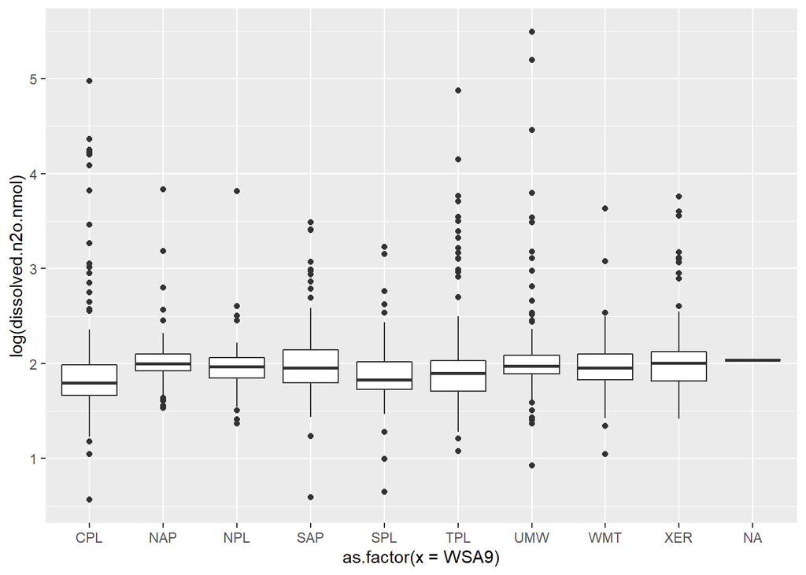

```r
dg %>%
  ggplot(aes(as.factor(x = WSA9), y = log(dissolved.n2o.nmol))) + geom_boxplot()
```

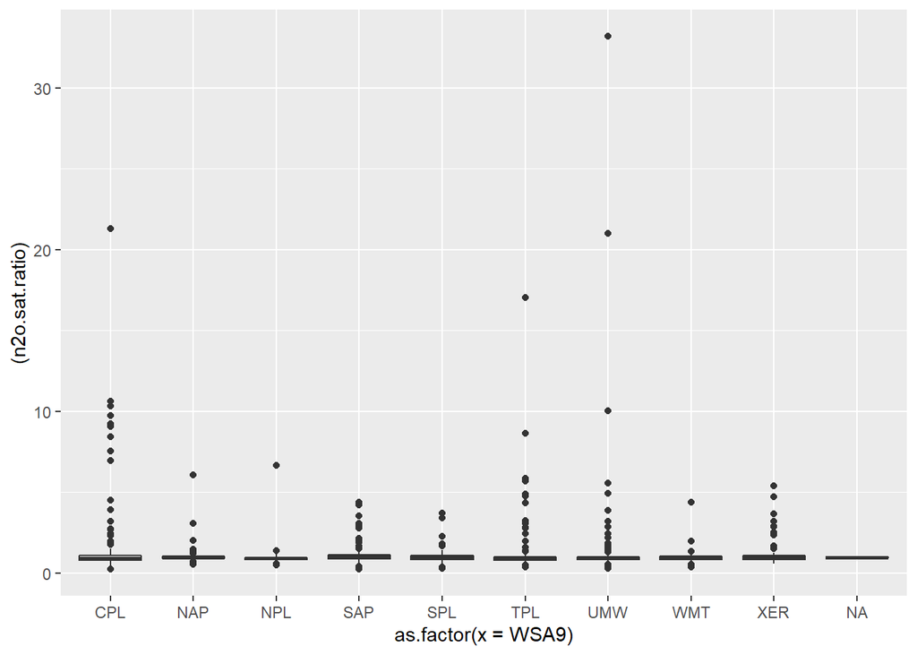

```r
dg %>%
  ggplot(aes(as.factor(x = WSA9), y = (n2o.sat.ratio))) + geom_boxplot()
```

# 2 Exploratory spatial analysis

## 2.1 Population estimates by ecoregion

### 2.1.1 Dissolved gas concentration

The survey design allows for population estimates of central tendency and variance by ecoregion (and other subpopulations), which can provide insight into spatial patterning. There is broad overlap in mean +/- 95% CI estimates for dissolved CH<sub>4</sub> and N<sub>2</sub>O concentration across ecoregions. The Northern Plains, Temperate Plains, and Western Mountains have low dissolved CO<sub>2</sub> concentration.

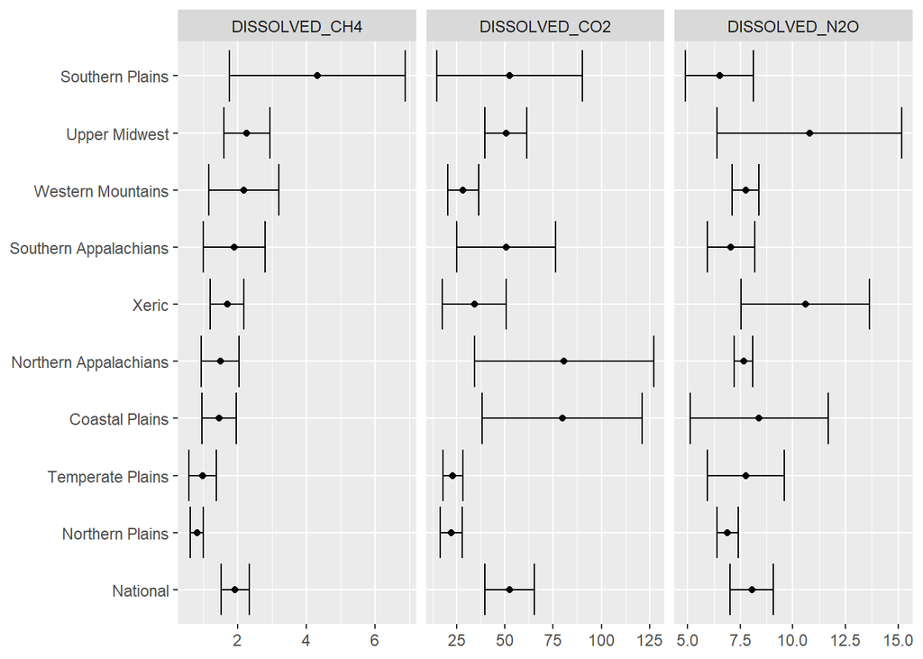

Fig. caption: Mean +/- 95% CI for the dissolved gas concentration indicator

```r
# Read population estimates calculated with local neighborhood variance estimate.  Code provided by Tom Kincaid
# (12/12/2019), then modified to accomdate the gas emission rate and flux variables.  See CDF_Estimates_Jb.Rmd.
pop <- read.csv(file = paste0(localPath,
                              "/Environmental Protection Agency (EPA)/",
                              "ORD NLA17 Dissolved Gas - Documents/",
                              "inputData/populationEstimates/",
                              "NLA_2017_Percentile_Estimates_Local_Mean_JB20201202.csv"),
                as.is = TRUE) %>%
  toEPA()  # enforce formatting convention

# Convert units for dissolved gas concentration indicator
pop <- pop %>%
  mutate(estimate = ifelse(grepl("dissolved.c", indicator, ignore.case = TRUE), # dissolved.co2 or dissolved.ch4
                            estimate * 1000000, # mol/L -> umol/L for co2 and ch4
                           ifelse(grepl("dissolved.n", indicator, ignore.case = TRUE), # dissolved.n2o
                            estimate * 1000000000, # mol/L -> nmol/L for n2o
                            estimate)), # all others
         lcb95pct = ifelse(grepl("dissolved.c", indicator, ignore.case = TRUE), # dissolved.co2 or dissolved.ch4
                            lcb95pct * 1000000, # mol/L -> umol/L for co2 and ch4
                           ifelse(grepl("dissolved.n", indicator, ignore.case = TRUE), # dissolved.n2o
                            lcb95pct * 1000000000, # mol/L -> nmol/L for n2o
                            lcb95pct)), # all others
         ucb95pct = ifelse(grepl("dissolved.c", indicator, ignore.case = TRUE), # dissolved.co2 or dissolved.ch4
                            ucb95pct * 1000000, # mol/L -> umol/L for co2 and ch4
                           ifelse(grepl("dissolved.n", indicator, ignore.case = TRUE), # dissolved.n2o
                            ucb95pct * 1000000000, # mol/L -> nmol/L for n2o
                            ucb95pct))) # all others


# extract population estimates for ecoregion and nation
pop.eco <- pop %>%
  filter(type %in% c("AG_ECO9_NM", "National"), # extract estimates for ecoregion and nation
         statistic == "Mean") # extract mean estimate

# extract dissolved gas indicator, order by dissolved CH4
pop.eco.diss <- pop.eco %>%
  filter(grepl("dissolved", indicator, ignore.case = TRUE)) %>%
  mutate(subpopulation = factor(subpopulation,
                             levels = filter(pop.eco, indicator == "DISSOLVED_CH4", subpopulation != "National") %>%
                               arrange(estimate) %>%
                               select(subpopulation) %>%
                               pull() %>%
                               c("National", .)))

# look at dissolved concentration indicator
ggplot(pop.eco.diss, aes(estimate, subpopulation)) +
  geom_point() +
  geom_errorbarh(aes(xmax = ucb95pct, xmin = lcb95pct)) +
  facet_wrap(~indicator, scales = "free_x") +
  theme(axis.title = element_blank())
```

### 2.1.2 Dissolved gas saturation ratios and source/sink status

Dissolved gas saturation ratios are calculated as the ratio of the observed to equilibrium concentration. The equilibrium concentration (sometimes called the saturation concentration) is the concentration expected if the waterbody were in equilibrium with the atmosphere. It is calculated from the partial pressure of the gas in the atmosphere, water temperature, and the gas specific solubility. Saturation ratios >1 indicate the water body is supersaturated and is a source of the gas to the atmosphere. Saturation ratios <1 indicate that the waterbody is undersaturated and is consuming the gas from the atmosphere. The saturation ratio can therefore be used to categorize each waterbody as a ‘sink’ or a ‘source’.

```r
# read in source/sink population data
# Read extent estimates generated with CDF_Estimates_Jb.Rmd.  File provided by Tom Kincaid (12/12/2019), then modified to accomodate the gas emission rate, flux variables, and cat.analysis for N2O source/sink.
n2o.extent <- read.csv(file = paste0(localPath,
                                     "/Environmental Protection Agency (EPA)/",
                                     "ORD NLA17 Dissolved Gas - Documents/",
                                     "inputData/populationEstimates/",
                                     "NLA_2017_Extent_Estimates20201203.csv"),
                       as.is = TRUE) %>%
  toEPA() %>% # enforce formatting convention
  filter(type %in% c("AG_ECO9_NM", "National"), # extract estimates for ecoregion and nation
         category == "sink") %>% # extract extent estimate for sink
  mutate(subpopulation = factor(subpopulation, # arrange by extent estimate for sink
                                levels = filter(., subpopulation != "National") %>%
                                  arrange(estimate.p) %>%
                                  select(subpopulation) %>%
                                  pull() %>%
                                  c("National", .)))
```

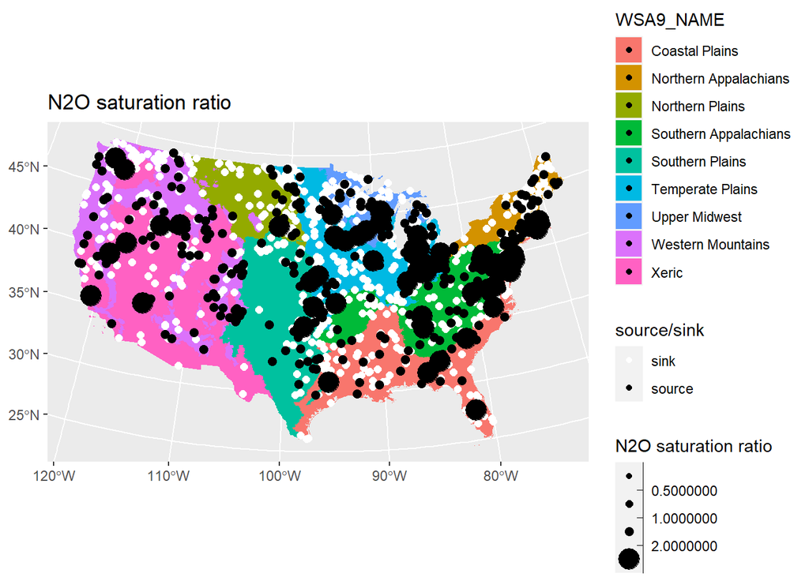

```r
## Bubble plot of observed N2O saturation index----------------
# To enable spatial analysis of the data, the dataframe will be converted to a 'simple features' (sf) object.
# Define coordinates
coords <- data.frame(longitude = dg$map.lon.dd, latitude = dg$map.lat.dd)

dg.sf <- st_as_sf(dg, coords = c("map.lon.dd", "map.lat.dd"),
                  crs = 4269) %>% # standard for lat/lon
  st_transform(5070) # project to CONUS ALBERS for plotting



# read in ecoregion polygons
ecoR <- st_read(dsn = paste0(localPath,
                             "/Environmental Protection Agency (EPA)/",
                             "ORD NLA17 Dissolved Gas - Documents/inputData"),
                layer = "aggr_ecoregions_simple")
# Check CRS
#st_crs(ecoR) # 3857
ecoR <- st_transform(ecoR, 5070) # convert to CONUS Albers
#st_crs(ecoR) # 5070

ggplot() +
  geom_sf(data = ecoR, color = NA, aes(fill = WSA9_NAME)) +
  geom_sf(data = dg.sf, aes(size = n2o.sat.ratio, color = n2o.src.snk),
          show.legend = "point") +
  ggtitle("N2O saturation ratio") +
  scale_color_manual(values = c("white", "black"), name = "source/sink") +
  scale_size_binned(name = "N2O saturation ratio",
             range = c(1, 8), # custom size range
             breaks = c(0.1, 0.5, 1, 2))  # custom breaks
```

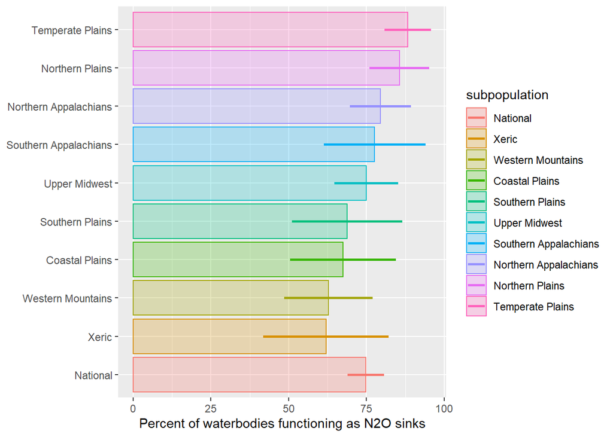

```r
## horizontal bar chart of N2O sink extent---------------
ggplot(n2o.extent, aes(estimate.p, subpopulation)) +
  geom_bar(stat = "identity", aes(fill = subpopulation, color = subpopulation), alpha = 0.25) +
  geom_errorbarh(aes(xmax = ucb95pct.p, xmin = lcb95pct.p, color = subpopulation), height = 0, size = 1) +
  xlab("Percent of waterbodies functioning as N2O sinks") +
  theme(axis.title.y = element_blank())
```

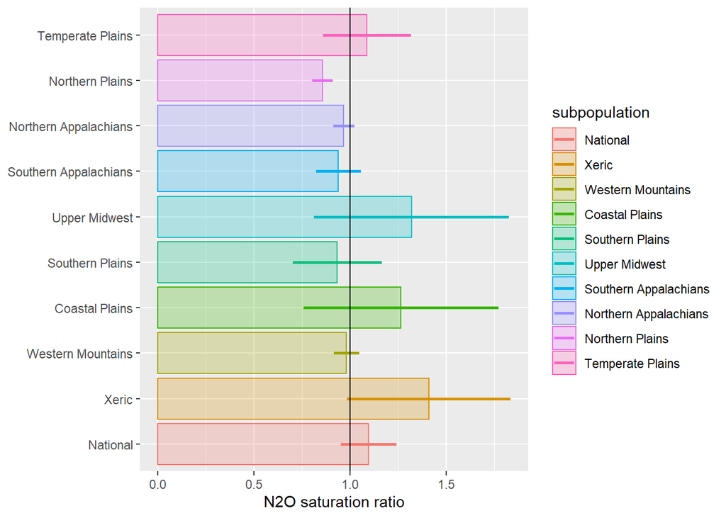

```r
## horizontal bar chart of N2O saturation ratio-------------
# extract saturation indicator, order by n2o extent (see above).  This enforces same order for both plots.
pop.eco.sat <- pop.eco %>%
  filter(grepl("sat", indicator, ignore.case = TRUE)) %>%
  mutate(subpopulation = factor(subpopulation,
                             levels = filter(n2o.extent, subpopulation != "National") %>%
                                  arrange(estimate.p) %>%
                                  select(subpopulation) %>%
                                  pull() %>%
                               as.character() %>%
                                  c("National", .)))

# N2O saturation ratio; horizontal bar chart
ggplot(filter(pop.eco.sat, indicator == "N2O_SAT_RATIO"), aes(estimate, subpopulation)) +
  geom_bar(stat = "identity", aes(fill = subpopulation, color = subpopulation), alpha = 0.25) +
  geom_errorbarh(aes(xmax = ucb95pct, xmin = lcb95pct, color = subpopulation), height = 0, size = 1) +
  xlab("N2O saturation ratio") +
  theme(axis.title.y = element_blank()) +
  geom_vline(xintercept = 1)
```

### 2.1.3 Emission rates and flux

The emission rate (E<sub>gas</sub>) is the rate at which a gas crosses the air water interface and is expressed on an areal basis (i.e. mass m<sup>-2</sup> day<sup>-1</sup>). It is calculated as a function of the dissolved gas concentration and gas transfer velocity (see dataMunge.Rmd). The 95% confidence interval of the mean N<sub>2</sub>O emission rate is quite large in several ecoregions, encompassing 0 in all but the Northen Plains and Xeric ecoregions. The mean N<sub>2</sub>O emission rate at the national scale is positive (0.6864 umol N<sub>2</sub>O m<sup>-2</sup> day<sup>-1</sup>), although the 95% confidence interval includes 0, similar to the N<sub>2</sub>O saturation ratio pattern.

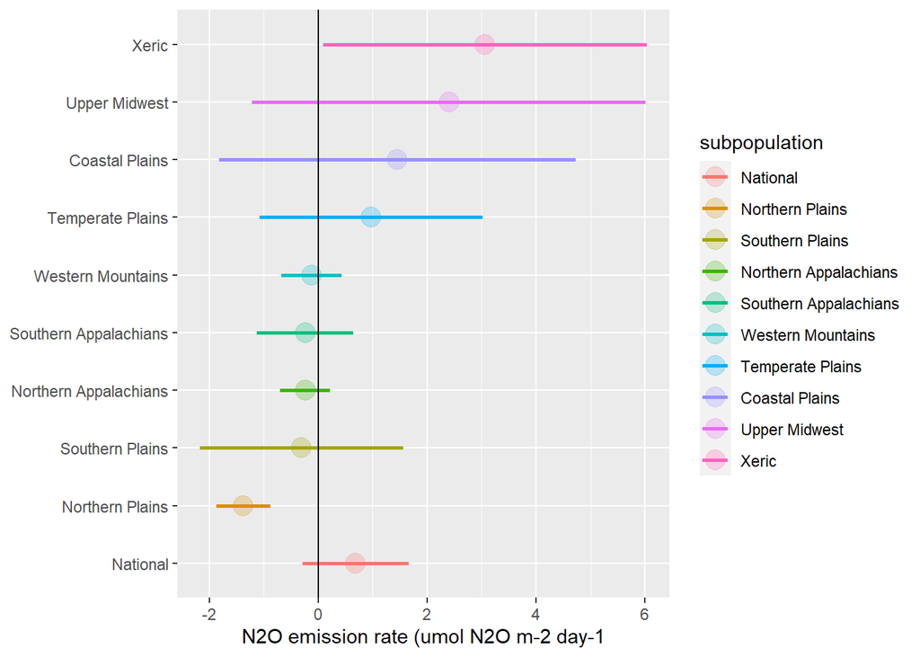

Fig. caption: Mean +/- 95% CI for the emission rate (mass of GHG time-1 area-1)

```r
# extract population estimates for ecoregion and nation
pop.eco.emission <- pop.eco %>%
  filter(grepl("^E", indicator)) %>% # ^ means starts with.  Extract the emission rates
  # order by N2O
   mutate(subpopulation = factor(subpopulation,
                             levels = filter(., indicator == "E_N2O_NMOL_D", subpopulation != "National") %>%
                               arrange(estimate) %>%
                               select(subpopulation) %>%
                               pull() %>%
                               c("National", .)))


# look at dissolved concentration indicator
ggplot(filter(pop.eco.emission, indicator == "E_N2O_NMOL_D"),
       aes(estimate/1000, subpopulation)) + # convert to umol
  geom_point(aes(color = subpopulation, fill = subpopulation), alpha = 0.25, size = 5) +
  geom_errorbarh(aes(xmax = ucb95pct/1000, xmin = lcb95pct/1000, color = subpopulation), height = 0, size = 1) + # convert to umol
  geom_vline(xintercept = 0) +
  xlab("N2O emission rate (umol N2O m-2 day-1") + # converted from nmol to umol (see above)
  theme(axis.title.y = element_blank())
```

The N<sub>2</sub>O flux at a waterbody is the total mass of N<sub>2</sub>O crossing the air-water interface per unit time (e.g. mass N<sub>2</sub>O day<sup>-1</sup>) and is calculated as the product of the emission rate (mass N<sub>2</sub>O m<sup>-2</sup> day<sup>-1</sup>) and waterbody area (m<sup>2</sup>). Negative values indicate N2O invasion into the waterbody and positive values indicate N<sub>2</sub>O efflux from the waterbody to the atmosphere. An assessment of the role of lakes and reservoirs in the atmospheric N<sub>2</sub>O budget must be based on flux, rather than emission rates, because flux accounts for waterbody size. For example, N<sub>2</sub>O emissions from several small waterbodies could be completely offset by N<sub>2</sub>O uptake by a single large waterbody with a small negative emission rate (e.g. N<sub>2</sub>O sink), yet the mean emission rate for these waterbodies would be > 0.

The mean N<sub>2</sub>O flux per waterbody is close to zero for most ecoregions and the 95% confidence interval includes zero for all ecoregions. The national scale mean N<sub>2</sub>O flux is slightly negative (-0.8 mol N<sub>2</sub>O day<sup>-1</sup>), but the 95% CI includes 0.

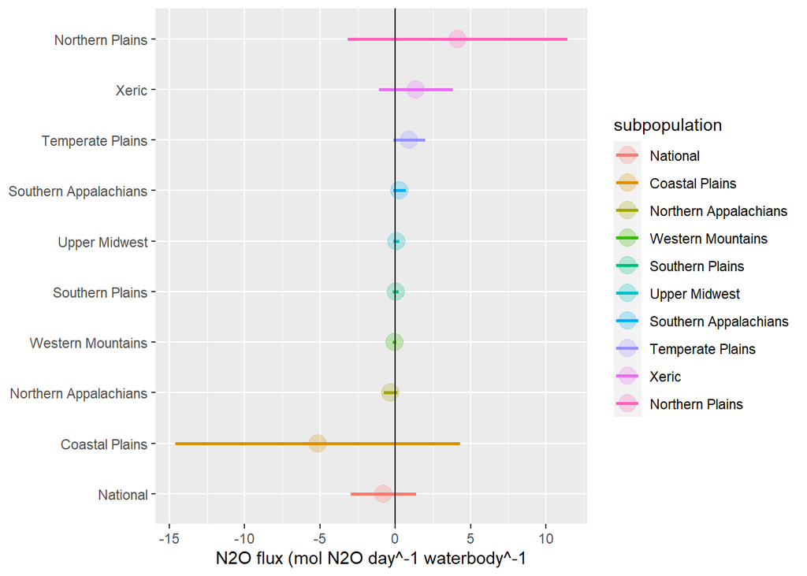

Fig. caption: Mean +/- 95% CI of the GHG flux across the air-water interface (mass GHG / time)

```r
# extract population estimates for ecoregion and nation
pop.eco.flux <- pop.eco %>%
  filter(grepl("^F", indicator)) %>% # ^ means starts with.  Extract the flux rates
  # order by N2O
   mutate(subpopulation = factor(subpopulation,
                             levels = filter(., indicator == "F_N2O_M_D", subpopulation != "National") %>%
                               arrange(estimate) %>%
                               select(subpopulation) %>%
                               pull() %>%
                               c("National", .)))


# look at dissolved concentration indicator
ggplot(filter(pop.eco.flux, indicator == "F_N2O_M_D"),
       aes(estimate, subpopulation)) +
  geom_point(aes(color = subpopulation, fill = subpopulation), alpha = 0.25, size = 5) +
  geom_errorbarh(aes(xmax = ucb95pct, xmin = lcb95pct, color = subpopulation), height = 0, size = 1) +
  geom_vline(xintercept = 0) +
  xlab("N2O flux (mol N2O day^-1 waterbody^-1") +
  theme(axis.title.y = element_blank())
```

### 2.1.4 13C paper

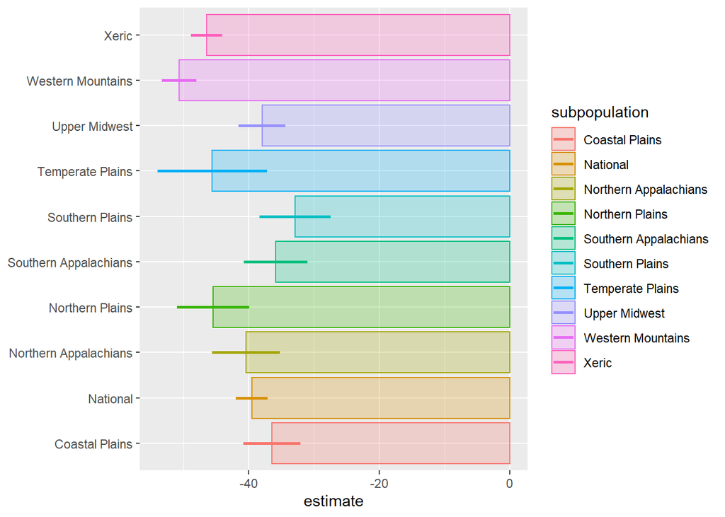

```r
# 13C; horizontal bar chart by ecoregion
pop.eco.13c <- filter(pop.eco, indicator == "DELTA_13_CH4_C")
ggplot(pop.eco.13c, aes(estimate, subpopulation)) +
  geom_bar(stat = "identity", aes(fill = subpopulation, color = subpopulation), alpha = 0.25) +
  geom_errorbarh(aes(xmax = ucb95pct, xmin = lcb95pct, color = subpopulation), height = 0, size = 1) +
  theme(axis.title.y = element_blank())
```

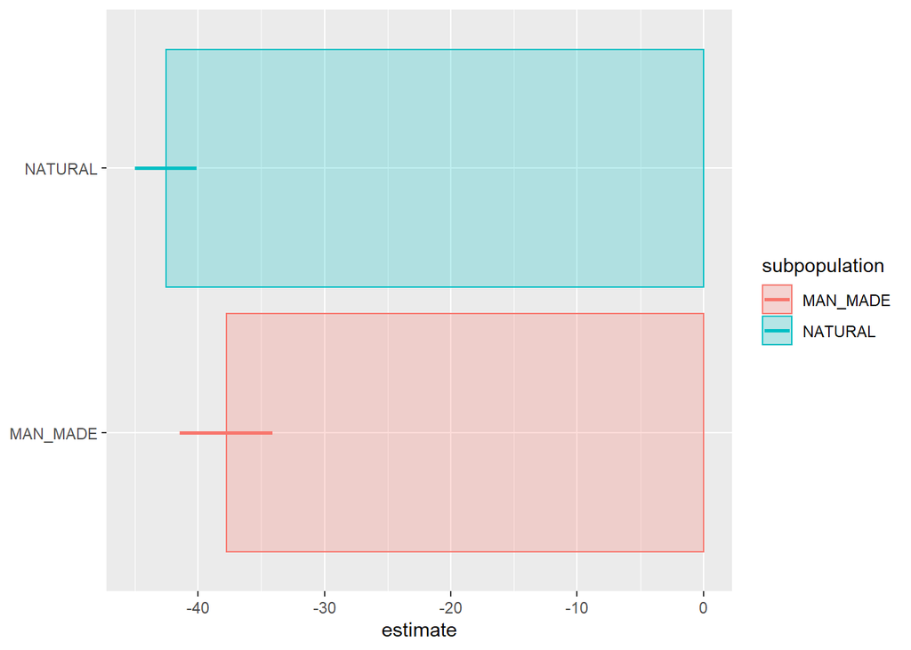

```r
# 13C; horizontal bar chart by origin
pop.origin.13c <- filter(pop, type == "LAKE_ORGN", statistic == "Mean", indicator == "DELTA_13_CH4_C")
ggplot(pop.origin.13c, aes(estimate, subpopulation)) +
  geom_bar(stat = "identity", aes(fill = subpopulation, color = subpopulation), alpha = 0.25) +
  geom_errorbarh(aes(xmax = ucb95pct, xmin = lcb95pct, color = subpopulation), height = 0, size = 1) +
  theme(axis.title.y = element_blank())
```

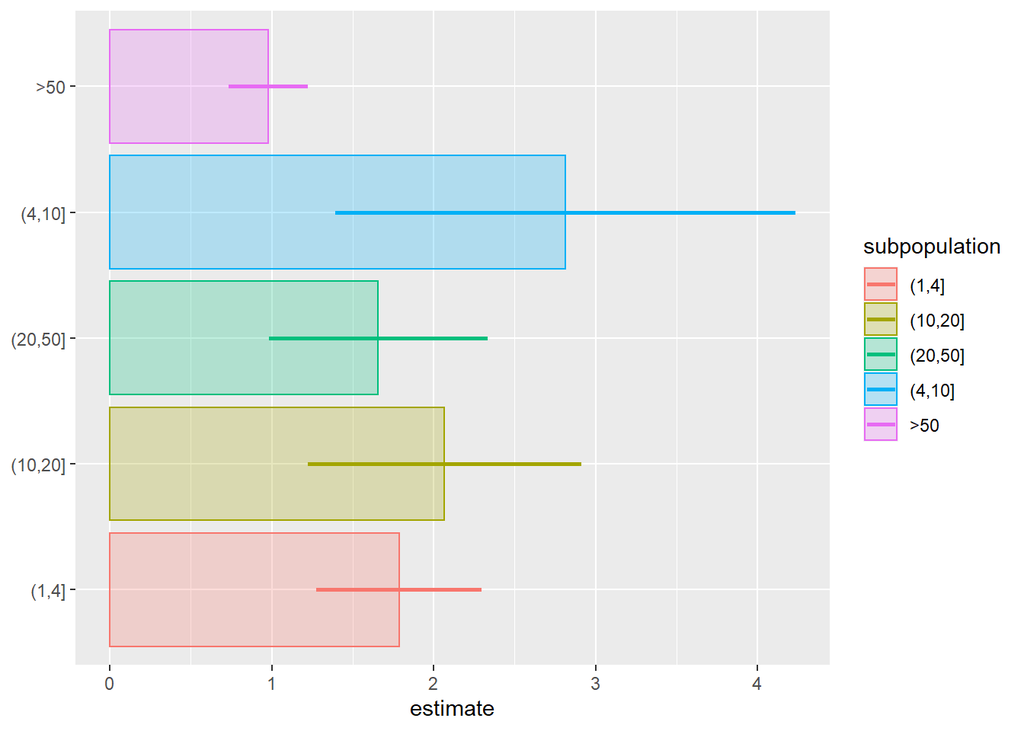

```r
# 13C; horizontal bar by size
pop.size.ch4 <- filter(pop, type == "AREA_CAT6", statistic == "Mean", indicator == "DISSOLVED_CH4")
ggplot(pop.size.ch4, aes(estimate, subpopulation)) +
  geom_bar(stat = "identity", aes(fill = subpopulation, color = subpopulation), alpha = 0.25) +
  geom_errorbarh(aes(xmax = ucb95pct, xmin = lcb95pct, color = subpopulation), height = 0, size = 1) +
  theme(axis.title.y = element_blank())
```

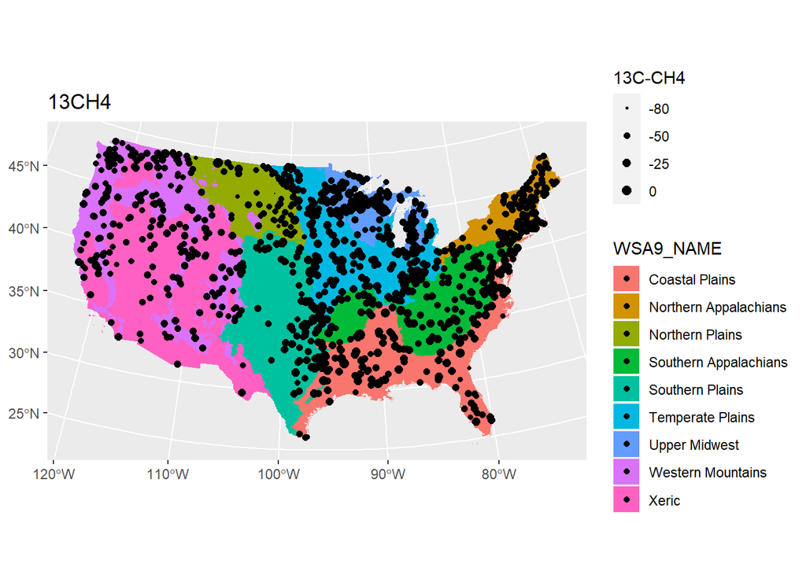

```r
# 13CH4 Bubble plots

ggplot() +
  geom_sf(data = ecoR, color = NA, aes(fill = WSA9_NAME)) +
  geom_sf(data = dg.sf, aes(size = delta.13.ch4),
          show.legend = "point") + # improve legend
  ggtitle("13CH4") +
  scale_size(name = "13C-CH4",
             range = c(0.05, 3), # custom size range
             breaks = c(-80, -50, -25, 0)) # custom breaks
```

Similarly, we can look at population level estimates of GHG emission rates (mass of GHG time<sup>-1</sup> area<sup>-1</sup>).

We can also look at the GHG flux across the air-water interface (mass GHG time<sup>-1</sup>)

## 2.2 Simple random sample vs local neighborhood variance estimator

Population level estimates of variance can be calculated using a simple random sample or local neighborhood estimators. The local neighborhood estimator will yield lower variance estimates if there is spatial structure in the data. Below are plotted the 95% confidence intervals calculated using both methods. In nearly all cases the local neighborhood estimator yields a more restricted interval.

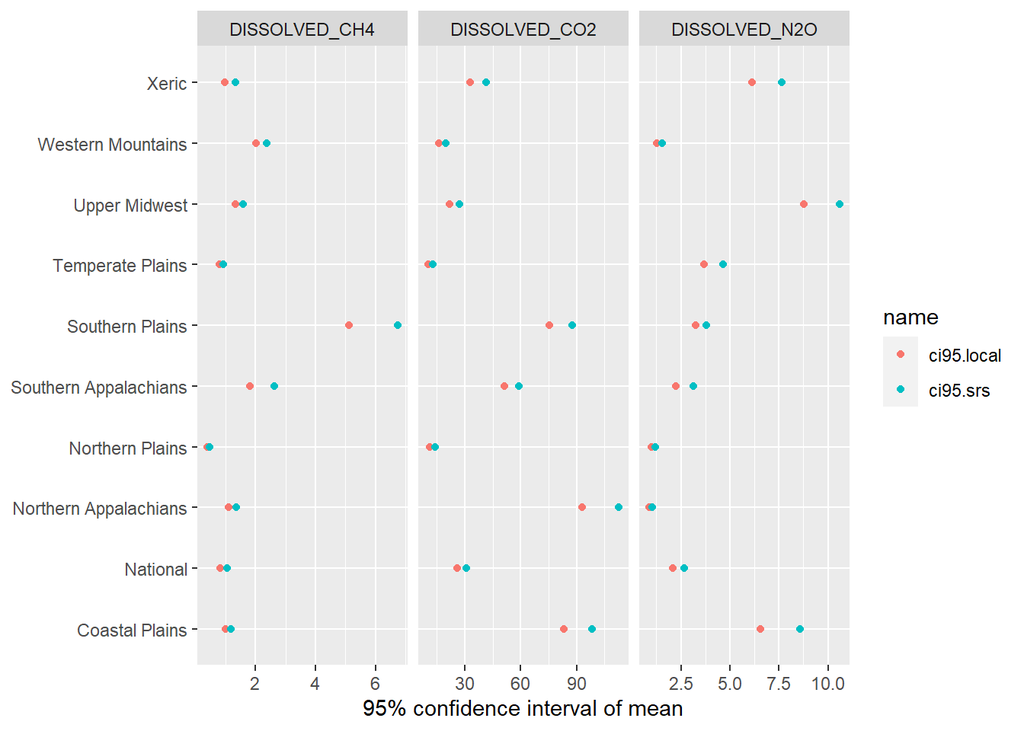

```r
# calculate 95% CI using local neighborhood estimator
pop.eco.diss <- pop.eco.diss %>%
  mutate(ci95.local = ucb95pct - lcb95pct)

# read in SRS estimator population estimates provided by Tom Kincaid (12/12/2019)
pop.srs <- read.csv(file = paste0(localPath,
                              "/Environmental Protection Agency (EPA)/",
                              "ORD NLA17 Dissolved Gas - Documents/",
                              "inputData/populationEstimates/",
                              "NLA_2017_Percentile_Estimates_SRS_20191212.csv"),
                as.is = TRUE) %>%
  toEPA()  # enforce formatting convention

# Convert units for dissolved gas concentration indicator
pop.srs <- pop.srs %>%
  mutate(estimate = ifelse(grepl("dissolved.c", indicator, ignore.case = TRUE), # dissolved.co2 or dissolved.ch4
                            estimate * 1000000, # mol/L -> umol/L for co2 and ch4
                           ifelse(grepl("dissolved.n", indicator, ignore.case = TRUE), # dissolved.n2o
                            estimate * 1000000000, # mol/L -> nmol/L for n2o
                            estimate)), # all others
         lcb95pct = ifelse(grepl("dissolved.c", indicator, ignore.case = TRUE), # dissolved.co2 or dissolved.ch4
                            lcb95pct * 1000000, # mol/L -> umol/L for co2 and ch4
                           ifelse(grepl("dissolved.n", indicator, ignore.case = TRUE), # dissolved.n2o
                            lcb95pct * 1000000000, # mol/L -> nmol/L for n2o
                            lcb95pct)), # all others
         ucb95pct = ifelse(grepl("dissolved.c", indicator, ignore.case = TRUE), # dissolved.co2 or dissolved.ch4
                            ucb95pct * 1000000, # mol/L -> umol/L for co2 and ch4
                           ifelse(grepl("dissolved.n", indicator, ignore.case = TRUE), # dissolved.n2o
                            ucb95pct * 1000000000, # mol/L -> nmol/L for n2o
                            ucb95pct))) # all others


# extract population estimates for ecoregion and nation
# dissolved gas indicator
pop.srs.eco.diss <- pop.srs %>%
  filter(type %in% c("AG_ECO9_NM", "National"), # extract estimates for ecoregion and nation
         statistic == "Mean") %>% # extract mean estimate
  mutate(ci95.srs = ucb95pct - lcb95pct) %>%
  filter(grepl("dissolved", indicator, ignore.case = TRUE))

# merge local neighborhood and SRS variance estimates
pop.local.srs <- dplyr::full_join(pop.eco.diss,
                                  select(pop.srs.eco.diss, -nresp, -estimate,
                                         -stderror, -lcb95pct, -ucb95pct)) %>%
  select(-nresp, -estimate, -stderror, -lcb95pct, -ucb95pct) %>%
  pivot_longer(cols = starts_with("ci95"))


# look at dissolved concentration indicator
ggplot(pop.local.srs, aes(value, subpopulation)) +
  geom_point(aes(color = name)) +
  facet_wrap(~indicator, scales = "free_x") +
  xlab("95% confidence interval of mean") +
  theme(axis.title.y = element_blank())
```

## 2.3 Bubble plots

Bubble plots can be used to visualize patterns in geospatial data. In the plots below, bubble size reflects the gas concentration and color reflects saturation status (i.e. source or sink). The code immediately below converts the dataframe to a spatial object and reads in the ecoregion ploygons. The first bubble plot below is of dissolved CO2 which seems to show a pattern of higher concentrations along the eastern seaboard.

```r
# To enable spatial analysis of the data, the dataframe will be converted to a 'simple features' (sf) object.
# Define coordinates
coords <- data.frame(longitude = dg$map.lon.dd, latitude = dg$map.lat.dd)

dg.sf <- st_as_sf(dg, coords = c("map.lon.dd", "map.lat.dd"),
                  crs = 4269) %>% # standard for lat/lon
  st_transform(5070) # project to CONUS ALBERS for plotting



# read in ecoregion polygons
ecoR <- st_read(dsn = paste0(localPath,
                             "/Environmental Protection Agency (EPA)/",
                             "ORD NLA17 Dissolved Gas - Documents/inputData"),
                layer = "aggr_ecoregions_simple")
# Check CRS
st_crs(ecoR) # 3857
```

```
## Coordinate Reference System:
##   User input: WGS 84 / Pseudo-Mercator
##   wkt:
## PROJCRS["WGS 84 / Pseudo-Mercator",
##     BASEGEOGCRS["WGS 84",
##         DATUM["World Geodetic System 1984",
##             ELLIPSOID["WGS 84",6378137,298.257223563,
##                 LENGTHUNIT["metre",1]]],
##         PRIMEM["Greenwich",0,
##             ANGLEUNIT["degree",0.0174532925199433]],
##         ID["EPSG",4326]],
##     CONVERSION["Popular Visualisation Pseudo-Mercator",
##         METHOD["Popular Visualisation Pseudo Mercator",
##             ID["EPSG",1024]],
##         PARAMETER["Latitude of natural origin",0,
##             ANGLEUNIT["degree",0.0174532925199433],
##             ID["EPSG",8801]],
##         PARAMETER["Longitude of natural origin",0,
##             ANGLEUNIT["degree",0.0174532925199433],
##             ID["EPSG",8802]],
##         PARAMETER["False easting",0,
##             LENGTHUNIT["metre",1],
##             ID["EPSG",8806]],
##         PARAMETER["False northing",0,
##             LENGTHUNIT["metre",1],
##             ID["EPSG",8807]]],
##     CS[Cartesian,2],
##         AXIS["easting (X)",east,
##             ORDER[1],
##             LENGTHUNIT["metre",1]],
##         AXIS["northing (Y)",north,
##             ORDER[2],
##             LENGTHUNIT["metre",1]],
##     USAGE[
##         SCOPE["unknown"],
##         AREA["World - 85Â°S to 85Â°N"],
##         BBOX[-85.06,-180,85.06,180]],
##     ID["EPSG",3857]]
```

```r
ecoR <- st_transform(ecoR, 5070) # convert to CONUS Albers
st_crs(ecoR) # 5070
```

```
## Coordinate Reference System:
##   User input: EPSG:5070
##   wkt:
## PROJCRS["NAD83 / Conus Albers",
##     BASEGEOGCRS["NAD83",
##         DATUM["North American Datum 1983",
##             ELLIPSOID["GRS 1980",6378137,298.257222101,
##                 LENGTHUNIT["metre",1]]],
##         PRIMEM["Greenwich",0,
##             ANGLEUNIT["degree",0.0174532925199433]],
##         ID["EPSG",4269]],
##     CONVERSION["Conus Albers",
##         METHOD["Albers Equal Area",
##             ID["EPSG",9822]],
##         PARAMETER["Latitude of false origin",23,
##             ANGLEUNIT["degree",0.0174532925199433],
##             ID["EPSG",8821]],
##         PARAMETER["Longitude of false origin",-96,
##             ANGLEUNIT["degree",0.0174532925199433],
##             ID["EPSG",8822]],
##         PARAMETER["Latitude of 1st standard parallel",29.5,
##             ANGLEUNIT["degree",0.0174532925199433],
##             ID["EPSG",8823]],
##         PARAMETER["Latitude of 2nd standard parallel",45.5,
##             ANGLEUNIT["degree",0.0174532925199433],
##             ID["EPSG",8824]],
##         PARAMETER["Easting at false origin",0,
##             LENGTHUNIT["metre",1],
##             ID["EPSG",8826]],
##         PARAMETER["Northing at false origin",0,
##             LENGTHUNIT["metre",1],
##             ID["EPSG",8827]]],
##     CS[Cartesian,2],
##         AXIS["easting (X)",east,
##             ORDER[1],
##             LENGTHUNIT["metre",1]],
##         AXIS["northing (Y)",north,
##             ORDER[2],
##             LENGTHUNIT["metre",1]],
##     USAGE[
##         SCOPE["unknown"],
##         AREA["USA - CONUS - onshore"],
##         BBOX[24.41,-124.79,49.38,-66.91]],
##     ID["EPSG",5070]]
```

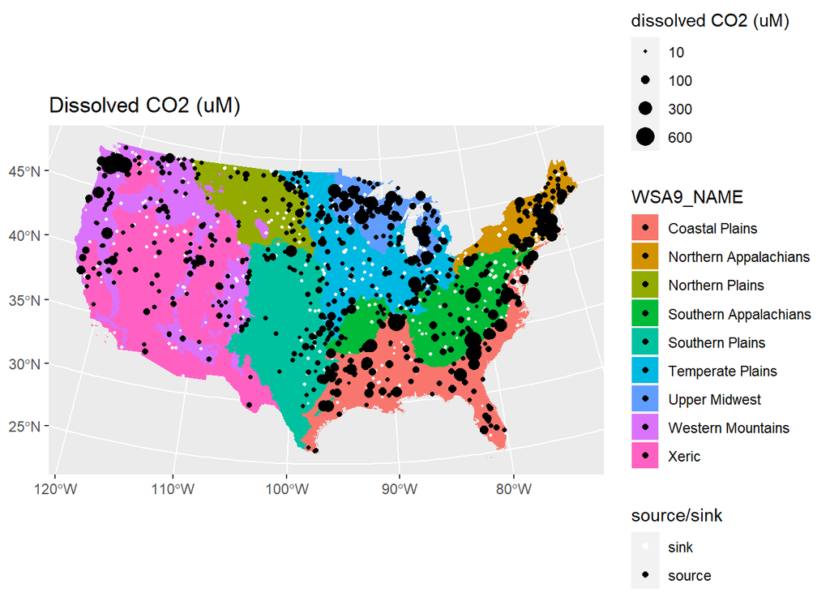

```r
# CO2 Bubble plots

ggplot() +
  geom_sf(data = ecoR, color = NA, aes(fill = WSA9_NAME)) +
  geom_sf(data = dg.sf, aes(size = dissolved.co2.umol, color = co2.src.snk),
          show.legend = "point") + # improve legend
  ggtitle("Dissolved CO2 (uM)") +
  scale_color_manual(values = c("white", "black"), name = "source/sink") +
  scale_size(name = "dissolved CO2 (uM)",
             range = c(0.1, 5), # custom size range
             breaks = c(10, 100, 300, 600)) # custom breaks
```

Spatial patterns in dissolved CH4 are not apparent, although all but two sites are supersaturated.

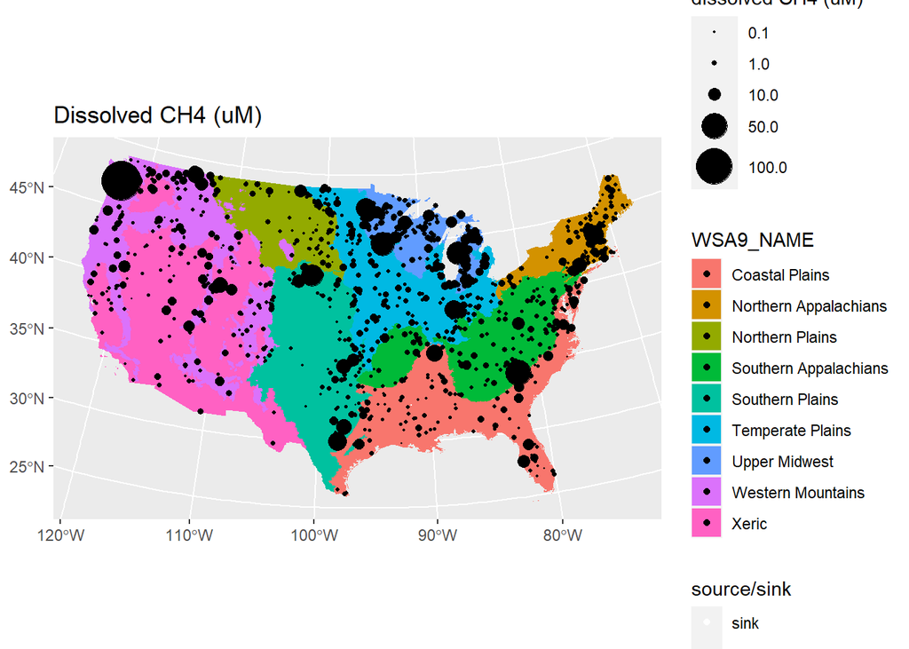

```r
ggplot() +
  geom_sf(data = ecoR, color = NA, aes(fill = WSA9_NAME)) +
  geom_sf(data = dg.sf, aes(size = dissolved.ch4.umol, color = ch4.src.snk),
          show.legend = "point") +
  ggtitle("Dissolved CH4 (uM)") +
  scale_color_manual(values = c("white", "black"), name = "source/sink") +
  scale_size(name = "dissolved CH4 (uM)",
             range = c(0.1, 10), # custom size range
             breaks = c(0.1, 1, 10, 50, 100)) # custom breaks
```

The prevalance of undersaturated dissolved N2O concentrations is an important finding. The IPCC assumes surface waters are an important source of N2O to the atmosphere. Webb et al. recently published a paper in PNAS reporting that 70 out of 101 reservoirs sampled in Saskatchewan were N2O sinks. This paper made quite a splash. In our study, 795 out of 1185 sampled waterbodies were an N2O sink. It is somewhat interesting to note that the some of the highest concentrations were observed in Indiana/Ohio, where I conducted much of my dissertation research on aquatic N2O emissions.

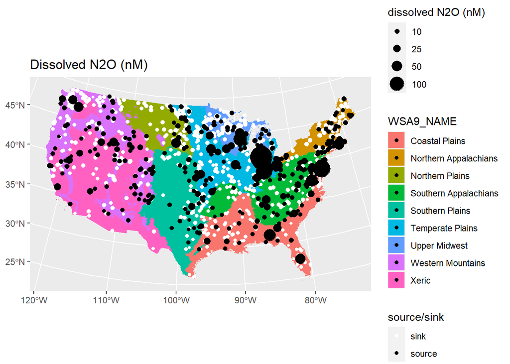

```r
ggplot() +
  geom_sf(data = ecoR, color = NA, aes(fill = WSA9_NAME)) +
  geom_sf(data = dg.sf, aes(size = dissolved.n2o.nmol, color = n2o.src.snk),
          show.legend = "point") +
  ggtitle("Dissolved N2O (nM)") +
  scale_color_manual(values = c("white", "black"), name = "source/sink") +
  scale_size(name = "dissolved N2O (nM)",
             range = c(0.1, 10), # custom size range
             breaks = c(1, 10, 25, 50, 100)) # custom breaks
```

## 2.4 Geopackage

Create a simple feature on entire dg data frame. The geopackage will contain two simple features, the dissolved gas sampled points/lakes and the nine aggregated ecoregions.

## 2.5 Summarizing distances

Getting distances between sites overall and by ecoregion to help set distances for lagged scatterplots. First, Worked out steps on a sample of NLA sites. Could only get parts of Anna Springsteen’s code to work.

## 2.6 Lagged scatterplots

Note that can use simple feature object, such as cpl, for histogram, but spatial object needed for lagged scatterplots. I took log10 transform to get data somewhat unimodal and symmetric.

## 2.7 k-NN = 1 and Moran plots

As with the lagged scatter plots, I had to take a simple feature object and convert it to a spatial object so I could use the nearest-neighbor and Moran scatter plot functions from the spdep package. A Moran plot is based on plotting the N<sub>2</sub>O variable, dissolved.n2o, of a focal point on the x-axis and the average dissolved.n2o of the neighboring points on the y-axis. Moran scatter plots were made for each of the 9 ecoregions and 1 for all of the NLA sites. For each plot, a neighborhood of points was defined by the maximum distance to first nearest neighbor. A distance-based spatial relationship was used because many of the ecoregions have several non-contiguous polygons or areas, which prevents a contiguity-based spatial relationship from being used. The slope of the line through the scatter plot of points measures spatial autocorrelation, with a positive slope indicating positive spatial autocorrelation.

```r
names(dg)
```

```
##   [1] "site.id"                   "visit.no"
##   [3] "sample.source"             "date.col"
##   [5] "n2o.ppm.gc_rpd"            "co2.ppm.gc_rpd"
##   [7] "co2.ppm.gc.adj_rpd"        "ch4.ppm.gc_rpd"
##   [9] "dissolved.co2_rpd"         "dissolved.co2.jb_rpd"
##  [11] "dissolved.ch4_rpd"         "dissolved.n2o_rpd"
##  [13] "co2.sat.ratio_rpd"         "ch4.sat.ratio_rpd"
##  [15] "n2o.sat.ratio_rpd"         "map.lat.dd"
##  [17] "map.lon.dd"                "n2o.ppm.gc"
##  [19] "co2.ppm.gc"                "co2.ppm.gc.adj"
##  [21] "ch4.ppm.gc"                "bp.kPa"
##  [23] "headtemp"                  "surftemp"
##  [25] "dissolved.co2.jb"          "co2.sat.ratio"
##  [27] "ch4.sat.ratio"             "n2o.sat.ratio"
##  [29] "co2.ppm.iso_rpd"           "ch4.ppm.iso_rpd"
```

[output cut: 183 more lines]

```r
# also includ WSA9, WSA9_NAME feature
dg_1 <- select(dg,site.id:dissolved.n2o.nmol, WSA9, WSA9_NAME)
names(dg_1)
```

```
##   [1] "site.id"                   "visit.no"
##   [3] "sample.source"             "date.col"
##   [5] "n2o.ppm.gc_rpd"            "co2.ppm.gc_rpd"
##   [7] "co2.ppm.gc.adj_rpd"        "ch4.ppm.gc_rpd"
##   [9] "dissolved.co2_rpd"         "dissolved.co2.jb_rpd"
##  [11] "dissolved.ch4_rpd"         "dissolved.n2o_rpd"
##  [13] "co2.sat.ratio_rpd"         "ch4.sat.ratio_rpd"
##  [15] "n2o.sat.ratio_rpd"         "map.lat.dd"
##  [17] "map.lon.dd"                "n2o.ppm.gc"
##  [19] "co2.ppm.gc"                "co2.ppm.gc.adj"
##  [21] "ch4.ppm.gc"                "bp.kPa"
##  [23] "headtemp"                  "surftemp"
##  [25] "dissolved.co2.jb"          "co2.sat.ratio"
##  [27] "ch4.sat.ratio"             "n2o.sat.ratio"
##  [29] "co2.ppm.iso_rpd"           "ch4.ppm.iso_rpd"
```

[output cut: 177 more lines]

```r
dg_1 <- clean_names(dg_1)
names(dg_1)
```

```
##   [1] "site_id"                         "visit_no"
##   [3] "sample_source"                   "date_col"
##   [5] "n2o_ppm_gc_rpd"                  "co2_ppm_gc_rpd"
##   [7] "co2_ppm_gc_adj_rpd"              "ch4_ppm_gc_rpd"
##   [9] "dissolved_co2_rpd"               "dissolved_co2_jb_rpd"
##  [11] "dissolved_ch4_rpd"               "dissolved_n2o_rpd"
##  [13] "co2_sat_ratio_rpd"               "ch4_sat_ratio_rpd"
##  [15] "n2o_sat_ratio_rpd"               "map_lat_dd"
##  [17] "map_lon_dd"                      "n2o_ppm_gc"
##  [19] "co2_ppm_gc"                      "co2_ppm_gc_adj"
##  [21] "ch4_ppm_gc"                      "bp_k_pa"
##  [23] "headtemp"                        "surftemp"
##  [25] "dissolved_co2_jb"                "co2_sat_ratio"
##  [27] "ch4_sat_ratio"                   "n2o_sat_ratio"
##  [29] "co2_ppm_iso_rpd"                 "ch4_ppm_iso_rpd"
```

[output cut: 177 more lines]

```r
distinct(dg_1, wsa9)
```

| wsa9 |
| --- |
| SAP |
| CPL |
| XER |
| WMT |
| SPL |
| NAP |
| TPL |
| UMW |
| NA |
| NPL |

```r
# To enable spatial analysis of the data, the dataframe will be converted to a 'simple features' (sf) object.
# Define coordinates
coords <- data.frame(longitude = dg_1$map_lon_dd, latitude = dg_1$map_lat_dd)

dg_sf1 <- st_as_sf(dg_1, coords = c("map_lon_dd", "map_lat_dd"),crs = 4269) %>% # standard for lat/lon
  st_transform(5070) # project to CONUS ALBERS for plotting

st_crs(dg_sf1)
```

```
## Coordinate Reference System:
##   User input: EPSG:5070
##   wkt:
## PROJCRS["NAD83 / Conus Albers",
##     BASEGEOGCRS["NAD83",
##         DATUM["North American Datum 1983",
##             ELLIPSOID["GRS 1980",6378137,298.257222101,
##                 LENGTHUNIT["metre",1]]],
##         PRIMEM["Greenwich",0,
##             ANGLEUNIT["degree",0.0174532925199433]],
##         ID["EPSG",4269]],
##     CONVERSION["Conus Albers",
##         METHOD["Albers Equal Area",
##             ID["EPSG",9822]],
##         PARAMETER["Latitude of false origin",23,
##             ANGLEUNIT["degree",0.0174532925199433],
##             ID["EPSG",8821]],
##         PARAMETER["Longitude of false origin",-96,
##             ANGLEUNIT["degree",0.0174532925199433],
##             ID["EPSG",8822]],
##         PARAMETER["Latitude of 1st standard parallel",29.5,
##             ANGLEUNIT["degree",0.0174532925199433],
##             ID["EPSG",8823]],
##         PARAMETER["Latitude of 2nd standard parallel",45.5,
##             ANGLEUNIT["degree",0.0174532925199433],
##             ID["EPSG",8824]],
##         PARAMETER["Easting at false origin",0,
##             LENGTHUNIT["metre",1],
##             ID["EPSG",8826]],
##         PARAMETER["Northing at false origin",0,
##             LENGTHUNIT["metre",1],
##             ID["EPSG",8827]]],
##     CS[Cartesian,2],
##         AXIS["easting (X)",east,
##             ORDER[1],
##             LENGTHUNIT["metre",1]],
##         AXIS["northing (Y)",north,
##             ORDER[2],
##             LENGTHUNIT["metre",1]],
##     USAGE[
##         SCOPE["unknown"],
##         AREA["USA - CONUS - onshore"],
##         BBOX[24.41,-124.79,49.38,-66.91]],
##     ID["EPSG",5070]]
```

```r
glimpse(dg_sf1)
```

```
## Observations: 1,185
## Variables: 383
## $ site_id                         <chr> "NLA17_AL-10001", "NLA17_AL-10...
## $ visit_no                        <int> 1, 2, 1, 1, 1, 2, 1, 1, 1, 1, ...
## $ sample_source                   <chr> "DG", "DG", "DG", "DG", "DG", ...
## $ date_col                        <chr> "07/10/2017", "08/14/2017", "0...
## $ n2o_ppm_gc_rpd                  <dbl> 0.3010525, 2.1836348, 1.812475...
## $ co2_ppm_gc_rpd                  <dbl> 9.10295287, 115.29238707, 5.29...
## $ co2_ppm_gc_adj_rpd              <dbl> 8.77043300, 102.19313262, 4.70...
## $ ch4_ppm_gc_rpd                  <dbl> 1.1904413, 10.1954792, 0.28617...
## $ dissolved_co2_rpd               <dbl> 10.17723844, 107.20638920, 5.1...
## $ dissolved_co2_jb_rpd            <dbl> 10.397554, 190.532544, 8.61943...
## $ dissolved_ch4_rpd               <dbl> 1.3513514, 10.9409190, 0.19782...
## $ dissolved_n2o_rpd               <dbl> 0.0000000, 2.6905830, 2.660989...
## $ co2_sat_ratio_rpd               <dbl> 10.17723844, 107.20638920, 5.1...
```

[output cut: 370 more lines]

```r
# Get ecoregion-specific NLA sites
## CPL
cpl <- dg_sf1 %>% filter(wsa9 == "CPL" & visit_no == 1 & sample_source == "DG")

cpl_sp <- as(cpl, "Spatial")
class(cpl_sp)
```

```
## [1] "SpatialPointsDataFrame"
## attr(,"package")
## [1] "sp"
```

```r
ds1coords <- coordinates(cpl_sp)
ds1nb1 <- knn2nb(knearneigh(ds1coords, k=1), row.names = cpl_sp$site_id)
# using the k=1 object to find the minimum distance at which all sites have a distance-based neighbor
dsnb1_dist <- unlist(nbdists(ds1nb1,ds1coords))
summary(dsnb1_dist)# use max distance from summary to assign distance to create neighbors
```

```
##    Min. 1st Qu.  Median    Mean 3rd Qu.    Max.
##    5339   22033   37236   46150   61446  134761
```

```r
dsnb1 <- dnearneigh(ds1coords, d1=0, d2=134761, row.names=cpl_sp$site_id, longlat=FALSE)
summary(dsnb1)
```

```
## Neighbour list object:
## Number of regions: 130
## Number of nonzero links: 742
## Percentage nonzero weights: 4.390533
## Average number of links: 5.707692
## Link number distribution:
##
##  1  2  3  4  5  6  7  8  9 10 11 12
##  9 13 17 12 13 14 10 16 12  4  7  3
## 9 least connected regions:
## NLA17_AR-10014 NLA17_FL-10002 NLA17_FL-10029 NLA17_GA-10001 NLA17_KY-10004 NLA17_LA-10004 NLA17_MA-10001 NLA17_MA-10019 NLA17_NC-10014 with 1 link
## 3 most connected regions:
## NLA17_DE-10001 NLA17_MD-10004 NLA17_MD-10015 with 12 links
```

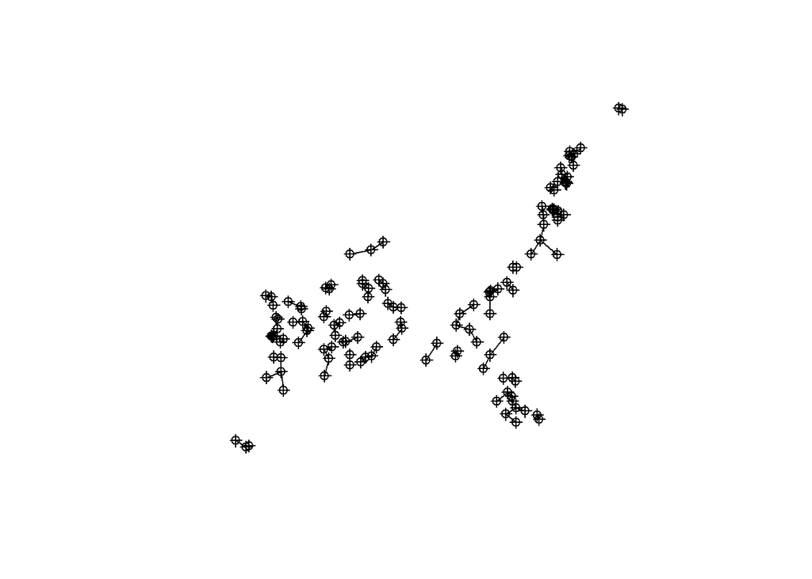

```r
plot(cpl_sp)
plot(ds1nb1, ds1coords, labels = cpl_sp$site_id, add = TRUE)
```

```r
dsnb1.listw <- nb2listw(dsnb1, style = "W")
summary(dsnb1.listw)
```

```
## Characteristics of weights list object:
## Neighbour list object:
## Number of regions: 130
## Number of nonzero links: 742
## Percentage nonzero weights: 4.390533
## Average number of links: 5.707692
## Link number distribution:
##
##  1  2  3  4  5  6  7  8  9 10 11 12
##  9 13 17 12 13 14 10 16 12  4  7  3
## 9 least connected regions:
## NLA17_AR-10014 NLA17_FL-10002 NLA17_FL-10029 NLA17_GA-10001 NLA17_KY-10004 NLA17_LA-10004 NLA17_MA-10001 NLA17_MA-10019 NLA17_NC-10014 with 1 link
## 3 most connected regions:
## NLA17_DE-10001 NLA17_MD-10004 NLA17_MD-10015 with 12 links
##
## Weights style: W
## Weights constants summary:
##     n    nn  S0       S1       S2
## W 130 16900 130 65.50514 535.2319
```

```r
class(cpl)
```

```
## [1] "sf"         "data.frame"
```

```r
# cpl_df <- st_drop_geometry(cpl)
# names(cpl_df)
summary(cpl$dissolved_n2o_nmol)
```

```
##    Min. 1st Qu.  Median    Mean 3rd Qu.    Max.
##   1.760   5.237   6.013  11.241   7.463 144.500
```

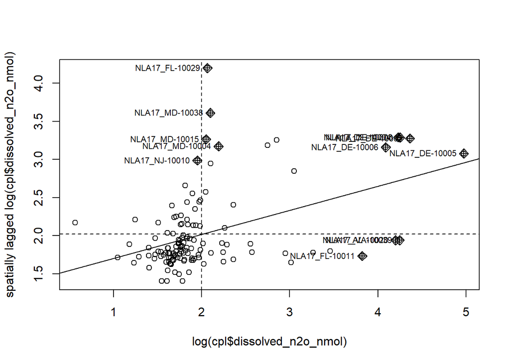

```r
moran.plot(log(cpl$dissolved_n2o_nmol), listw = dsnb1.listw, labels = cpl$site_id)
```

```r
rm(ds1coords, ds1nb1, dsnb1, dsnb1.listw, dsnb1_dist)

## NAP
nap <- dg_sf1 %>% filter(wsa9 == "NAP" & visit_no == 1 & sample_source == "DG")

nap_sp <- as(nap, "Spatial")
class(nap_sp)
```

```
## [1] "SpatialPointsDataFrame"
## attr(,"package")
## [1] "sp"
```

```r
ds1coords <- coordinates(nap_sp)
ds1nb1 <- knn2nb(knearneigh(ds1coords, k=1), row.names = nap_sp$site_id)
# using the k=1 object to find the minimum distance at which all sites have a distance-based neighbor
dsnb1_dist <- unlist(nbdists(ds1nb1,ds1coords))
summary(dsnb1_dist)# use max distance from summary to assign distance to create neighbors
```

```
##    Min. 1st Qu.  Median    Mean 3rd Qu.    Max.
##    2404   14697   23726   27247   38116  112627
```

```r
dsnb1 <- dnearneigh(ds1coords, d1=0, d2=112630, row.names=nap_sp$site_id, longlat=FALSE)
summary(dsnb1)
```

```
## Neighbour list object:
## Number of regions: 108
## Number of nonzero links: 1410
## Percentage nonzero weights: 12.08848
## Average number of links: 13.05556
## Link number distribution:
##
##  1  2  3  4  5  6  7  8  9 10 11 12 13 14 15 16 17 18 19 20 21 22 24 25 26
##  3  1  1  2 13  1  5  6 13  3  3  2  3  1  5  7  6  3 11  7  3  2  2  1  1
## 28 29
##  2  1
## 3 least connected regions:
## NLA17_NY-10001 NLA17_NY-10025 NLA17_PA-HP002 with 1 link
## 1 most connected region:
## NLA17_MA-10018 with 29 links
```

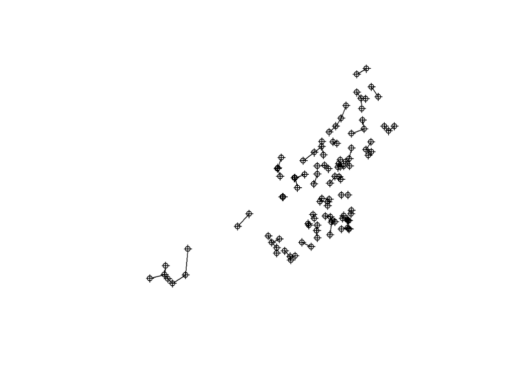

```r
plot(nap_sp)
plot(ds1nb1, ds1coords, labels = nap_sp$site_id, add = TRUE)
```

```r
dsnb1.listw <- nb2listw(dsnb1, style = "W")
summary(dsnb1.listw)
```

```
## Characteristics of weights list object:
## Neighbour list object:
## Number of regions: 108
## Number of nonzero links: 1410
## Percentage nonzero weights: 12.08848
## Average number of links: 13.05556
## Link number distribution:
##
##  1  2  3  4  5  6  7  8  9 10 11 12 13 14 15 16 17 18 19 20 21 22 24 25 26
##  3  1  1  2 13  1  5  6 13  3  3  2  3  1  5  7  6  3 11  7  3  2  2  1  1
## 28 29
##  2  1
## 3 least connected regions:
## NLA17_NY-10001 NLA17_NY-10025 NLA17_PA-HP002 with 1 link
## 1 most connected region:
## NLA17_MA-10018 with 29 links
##
## Weights style: W
## Weights constants summary:
##     n    nn  S0       S1       S2
## W 108 11664 108 26.00687 439.5393
```

```r
class(nap)
```

```
## [1] "sf"         "data.frame"
```

```r
# nap_df <- st_drop_geometry(nap)
# names(nap_df)
summary(nap$dissolved_n2o_nmol)
```

```
##    Min. 1st Qu.  Median    Mean 3rd Qu.    Max.
##   4.620   6.796   7.367   8.069   8.096  46.350
```

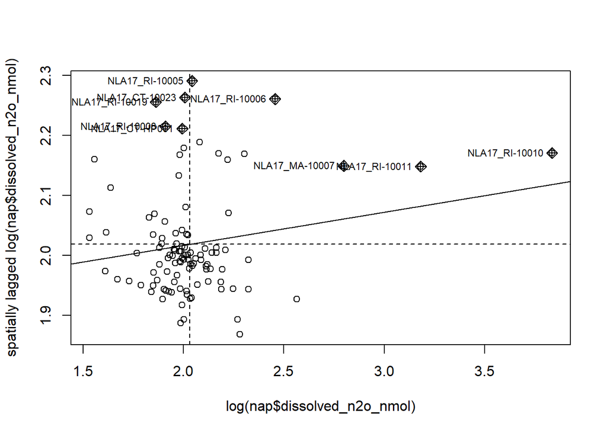

```r
moran.plot(log(nap$dissolved_n2o_nmol), listw = dsnb1.listw, labels = nap$site_id)
```

```r
rm(ds1coords, ds1nb1, dsnb1, dsnb1.listw, dsnb1_dist)

## NPL
npl <- dg_sf1 %>% filter(wsa9 == "NPL" & visit_no == 1 & sample_source == "DG")

npl_sp <- as(npl, "Spatial")
class(npl_sp)
```

```
## [1] "SpatialPointsDataFrame"
## attr(,"package")
## [1] "sp"
```

```r
ds1coords <- coordinates(npl_sp)
ds1nb1 <- knn2nb(knearneigh(ds1coords, k=1), row.names = npl_sp$site_id)
# using the k=1 object to find the minimum distance at which all sites have a distance-based neighbor
dsnb1_dist <- unlist(nbdists(ds1nb1,ds1coords))
summary(dsnb1_dist)# use max distance from summary to assign distance to create neighbors
```

```
##    Min. 1st Qu.  Median    Mean 3rd Qu.    Max.
##    1754   11988   32814   38150   49381  215393
```

```r
dsnb1 <- dnearneigh(ds1coords, d1=0, d2=215395, row.names=npl_sp$site_id, longlat=FALSE)
summary(dsnb1)
```

```
## Neighbour list object:
## Number of regions: 80
## Number of nonzero links: 1552
## Percentage nonzero weights: 24.25
## Average number of links: 19.4
## Link number distribution:
##
##  1  2  3  4  5  6  7  8 12 13 14 15 16 17 18 20 21 22 23 24 25 26 27 28 29
##  1  1  2  1  9  4  1  2  4  2  1  2  2  1  5  3  2  2  1  2  2  1  2  3  6
## 30 31 32 33 34 35 36 38 40
##  5  5  2  1  1  1  1  1  1
## 1 least connected region:
## NLA17_MT-10013 with 1 link
## 1 most connected region:
## NLA17_SD-10035 with 40 links
```

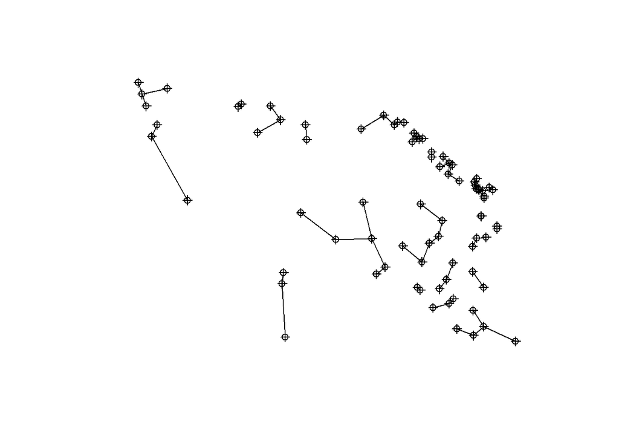

```r
plot(npl_sp)
plot(ds1nb1, ds1coords, labels = npl_sp$site_id, add = TRUE)
```

```r
dsnb1.listw <- nb2listw(dsnb1, style = "W")
summary(dsnb1.listw)
```

```
## Characteristics of weights list object:
## Neighbour list object:
## Number of regions: 80
## Number of nonzero links: 1552
## Percentage nonzero weights: 24.25
## Average number of links: 19.4
## Link number distribution:
##
##  1  2  3  4  5  6  7  8 12 13 14 15 16 17 18 20 21 22 23 24 25 26 27 28 29
##  1  1  2  1  9  4  1  2  4  2  1  2  2  1  5  3  2  2  1  2  2  1  2  3  6
## 30 31 32 33 34 35 36 38 40
##  5  5  2  1  1  1  1  1  1
## 1 least connected region:
## NLA17_MT-10013 with 1 link
## 1 most connected region:
## NLA17_SD-10035 with 40 links
##
## Weights style: W
## Weights constants summary:
##    n   nn S0       S1       S2
## W 80 6400 80 14.63402 325.2697
```

```r
class(npl)
```

```
## [1] "sf"         "data.frame"
```

```r
# npl_df <- st_drop_geometry(npl)
# names(npl_df)
summary(npl$dissolved_n2o_nmol)
```

```
##    Min. 1st Qu.  Median    Mean 3rd Qu.    Max.
##   3.935   6.272   7.115   7.554   7.815  45.450
```

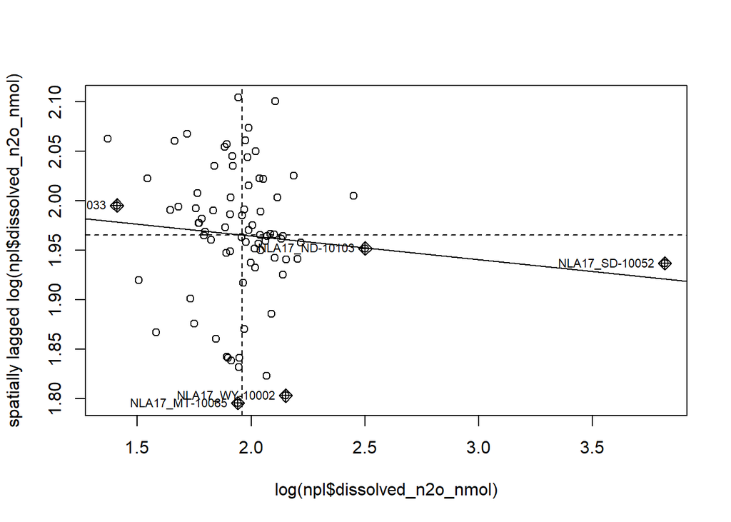

```r
moran.plot(log(npl$dissolved_n2o_nmol), listw = dsnb1.listw, labels = npl$site_id)
```

```r
rm(ds1coords, ds1nb1, dsnb1, dsnb1.listw, dsnb1_dist)

## SAP
sap <- dg_sf1 %>% filter(wsa9 == "SAP" & visit_no == 1 & sample_source == "DG")

sap_sp <- as(sap, "Spatial")
class(sap_sp)
```

```
## [1] "SpatialPointsDataFrame"
## attr(,"package")
## [1] "sp"
```

```r
ds1coords <- coordinates(sap_sp)
ds1nb1 <- knn2nb(knearneigh(ds1coords, k=1), row.names = sap_sp$site_id)
# using the k=1 object to find the minimum distance at which all sites have a distance-based neighbor
dsnb1_dist <- unlist(nbdists(ds1nb1,ds1coords))
summary(dsnb1_dist)# use max distance from summary to assign distance to create neighbors
```

```
##    Min. 1st Qu.  Median    Mean 3rd Qu.    Max.
##    6716   21890   37150   45838   68188  128285
```

```r
dsnb1 <- dnearneigh(ds1coords, d1=0, d2=128285, row.names=sap_sp$site_id, longlat=FALSE)
summary(dsnb1)
```

```
## Neighbour list object:
## Number of regions: 115
## Number of nonzero links: 696
## Percentage nonzero weights: 5.26276
## Average number of links: 6.052174
## Link number distribution:
##
##  1  2  3  4  5  6  7  8  9 10 11 15
##  5 10 13 14  5 18  8 16 14  7  3  2
## 5 least connected regions:
## NLA17_AR-10002 NLA17_AR-HP001 NLA17_IL-10007 NLA17_MO-10004 NLA17_OH-10038 with 1 link
## 2 most connected regions:
## NLA17_VA-10036 NLA17_WV-10003 with 15 links
```

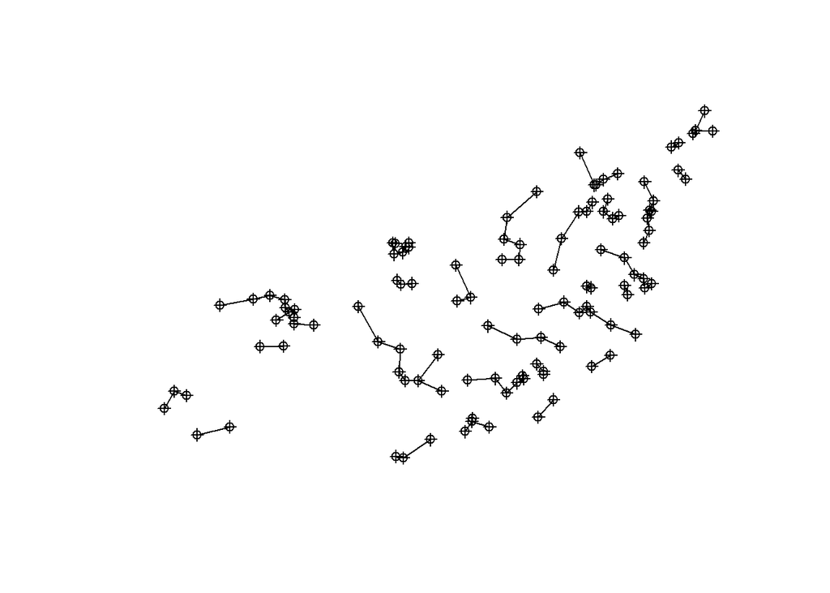

```r
plot(sap_sp)
plot(ds1nb1, ds1coords, labels = sap_sp$site_id, add = TRUE)
```

```r
dsnb1.listw <- nb2listw(dsnb1, style = "W")
summary(dsnb1.listw)
```

```
## Characteristics of weights list object:
## Neighbour list object:
## Number of regions: 115
## Number of nonzero links: 696
## Percentage nonzero weights: 5.26276
## Average number of links: 6.052174
## Link number distribution:
##
##  1  2  3  4  5  6  7  8  9 10 11 15
##  5 10 13 14  5 18  8 16 14  7  3  2
## 5 least connected regions:
## NLA17_AR-10002 NLA17_AR-HP001 NLA17_IL-10007 NLA17_MO-10004 NLA17_OH-10038 with 1 link
## 2 most connected regions:
## NLA17_VA-10036 NLA17_WV-10003 with 15 links
##
## Weights style: W
## Weights constants summary:
##     n    nn  S0       S1       S2
## W 115 13225 115 51.79175 469.8604
```

```r
class(sap)
```

```
## [1] "sf"         "data.frame"
```

```r
# sap_df <- st_drop_geometry(sap)
# names(sap_df)
summary(sap$dissolved_n2o_nmol)
```

```
##    Min. 1st Qu.  Median    Mean 3rd Qu.    Max.
##   1.810   5.997   7.035   8.179   8.390  32.750
```

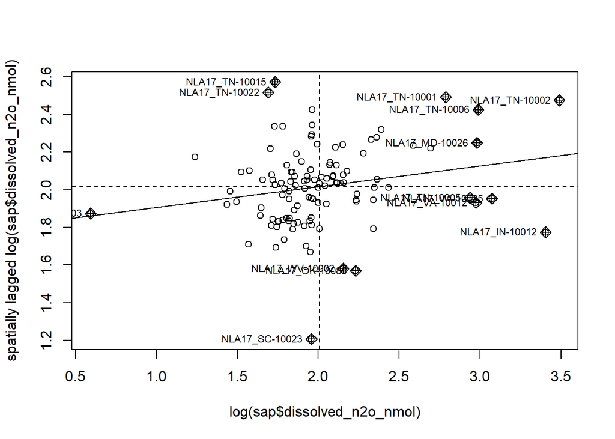

```r
moran.plot(log(sap$dissolved_n2o_nmol), listw = dsnb1.listw, labels = sap$site_id)
```

```r
rm(ds1coords, ds1nb1, dsnb1, dsnb1.listw, dsnb1_dist)

## SPL
spl <- dg_sf1 %>% filter(wsa9 == "SPL" & visit_no == 1 & sample_source == "DG")

spl_sp <- as(spl, "Spatial")
class(spl_sp)
```

```
## [1] "SpatialPointsDataFrame"
## attr(,"package")
## [1] "sp"
```

```r
ds1coords <- coordinates(spl_sp)
ds1nb1 <- knn2nb(knearneigh(ds1coords, k=1), row.names = spl_sp$site_id)
# using the k=1 object to find the minimum distance at which all sites have a distance-based neighbor
dsnb1_dist <- unlist(nbdists(ds1nb1,ds1coords))
summary(dsnb1_dist)# use max distance from summary to assign distance to create neighbors
```

```
##     Min.  1st Qu.   Median     Mean  3rd Qu.     Max.
##    926.4  14621.7  29653.8  40051.1  56297.6 173393.0
```

```r
dsnb1 <- dnearneigh(ds1coords, d1=0, d2=173395, row.names=spl_sp$site_id, longlat=FALSE)
summary(dsnb1)
```

```
## Neighbour list object:
## Number of regions: 97
## Number of nonzero links: 1030
## Percentage nonzero weights: 10.94697
## Average number of links: 10.61856
## Link number distribution:
##
##  1  2  3  4  5  6  7  8  9 10 11 12 13 14 15 16 17 18 19 20 21 22
##  2  3  1  7  4  6  7 16  1 10  5  3  5  5  2  2  1  3  4  2  2  6
## 2 least connected regions:
## NLA17_TX-10004 NLA17_TX-10020 with 1 link
## 6 most connected regions:
## NLA17_OK-10003 NLA17_OK-10010 NLA17_OK-10012 NLA17_OK-10019 NLA17_OK-10050 NLA17_OK-10098 with 22 links
```

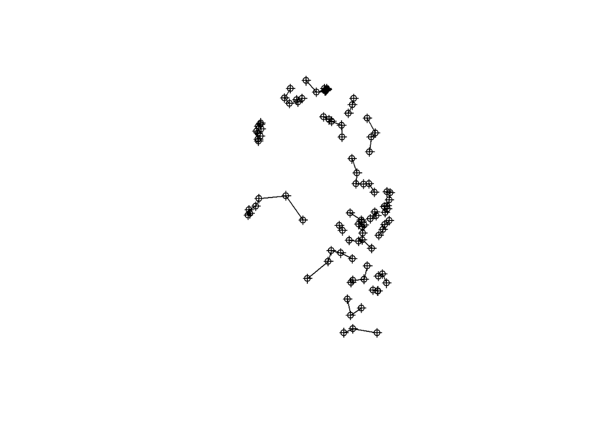

```r
plot(spl_sp)
plot(ds1nb1, ds1coords, labels = spl_sp$site_id, add = TRUE)
```

```r
dsnb1.listw <- nb2listw(dsnb1, style = "W")
summary(dsnb1.listw)
```

```
## Characteristics of weights list object:
## Neighbour list object:
## Number of regions: 97
## Number of nonzero links: 1030
## Percentage nonzero weights: 10.94697
## Average number of links: 10.61856
## Link number distribution:
##
##  1  2  3  4  5  6  7  8  9 10 11 12 13 14 15 16 17 18 19 20 21 22
##  2  3  1  7  4  6  7 16  1 10  5  3  5  5  2  2  1  3  4  2  2  6
## 2 least connected regions:
## NLA17_TX-10004 NLA17_TX-10020 with 1 link
## 6 most connected regions:
## NLA17_OK-10003 NLA17_OK-10010 NLA17_OK-10012 NLA17_OK-10019 NLA17_OK-10050 NLA17_OK-10098 with 22 links
##
## Weights style: W
## Weights constants summary:
##    n   nn S0       S1       S2
## W 97 9409 97 26.34555 393.5833
```

```r
class(spl)
```

```
## [1] "sf"         "data.frame"
```

```r
# spl_df <- st_drop_geometry(spl)
# names(spl_df)
summary(spl$dissolved_n2o_nmol)
```

```
##    Min. 1st Qu.  Median    Mean 3rd Qu.    Max.
##   1.920   5.630   6.230   7.035   7.525  25.250
```

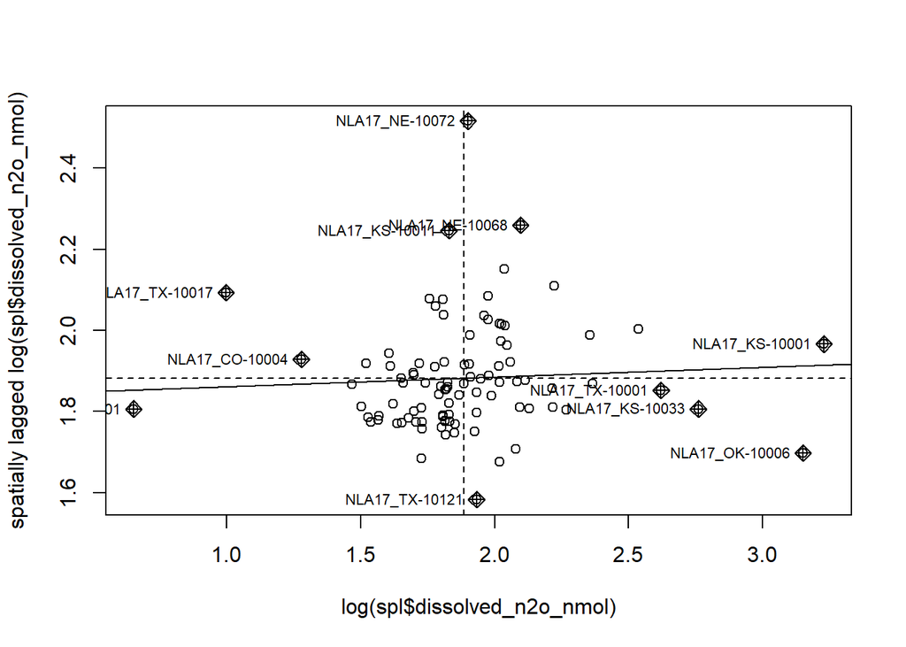

```r
moran.plot(log(spl$dissolved_n2o_nmol), listw = dsnb1.listw, labels = spl$site_id)
```

```r
rm(ds1coords, ds1nb1, dsnb1, dsnb1.listw, dsnb1_dist)

## TPL
tpl <- dg_sf1 %>% filter(wsa9 == "TPL" & visit_no == 1 & sample_source == "DG")

tpl_sp <- as(tpl, "Spatial")
class(tpl_sp)
```

```
## [1] "SpatialPointsDataFrame"
## attr(,"package")
## [1] "sp"
```

```r
nrow(zerodist(tpl_sp)) # indicates 1 pair of identical coordinates
```

```
## [1] 0
```

```r
(zerodist(tpl_sp)) # this gives the row numbers of the pair 30 & 36
```

```
##      [,1] [,2]
```

```r
View(tpl) # to view rows 30, site_id NLA17_IN-10002, & 36, NLA17_IN-10047

# Warning message from code below:
# In knearneigh(ds1coords, k = 1) : knearneigh: identical points found

ds1coords <- coordinates(tpl_sp)
ds1nb1 <- knn2nb(knearneigh(ds1coords, k=1), row.names = tpl_sp$site_id)
# using the k=1 object to find the minimum distance at which all sites have a distance-based neighbor
dsnb1_dist <- unlist(nbdists(ds1nb1,ds1coords))
summary(dsnb1_dist)# use max distance from summary to assign distance to create neighbors
```

```
##    Min. 1st Qu.  Median    Mean 3rd Qu.    Max.
##    1861   16563   26968   34799   46228  223893
```

```r
dsnb1 <- dnearneigh(ds1coords, d1=0, d2=223893, row.names=tpl_sp$site_id, longlat=FALSE)
summary(dsnb1)
```

```
## Neighbour list object:
## Number of regions: 160
## Number of nonzero links: 2994
## Percentage nonzero weights: 11.69531
## Average number of links: 18.7125
## Link number distribution:
##
##  1  6  7  8  9 10 11 12 13 14 15 16 17 18 19 20 21 22 23 24 25 26 27 28 29
##  1  1  3  1  1  7  2  7  6  8 10  8  6 18 14  9  7 13  4 10  4  4  5  5  1
## 30 32 33
##  1  2  2
## 1 least connected region:
## NLA17_MI-10095 with 1 link
## 2 most connected regions:
## NLA17_IN-10122 NLA17_IN-10142 with 33 links
```

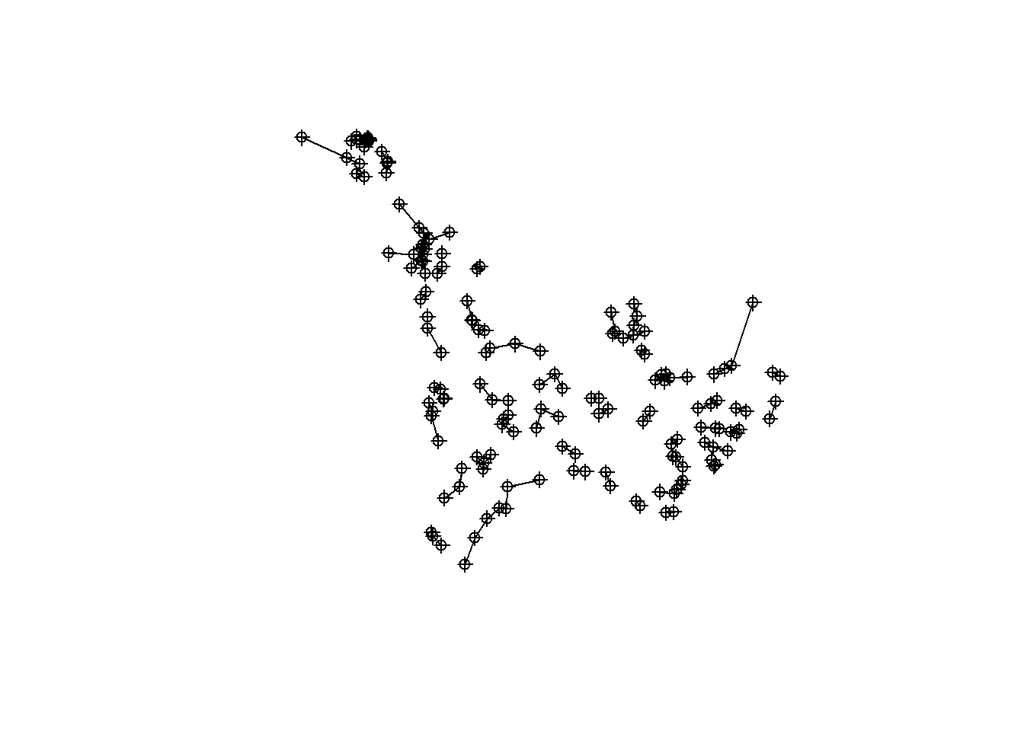

```r
plot(tpl_sp)
plot(ds1nb1, ds1coords, labels = tpl_sp$site_id, add = TRUE)
```

```r
dsnb1.listw <- nb2listw(dsnb1, style = "W")
summary(dsnb1.listw)
```

```
## Characteristics of weights list object:
## Neighbour list object:
## Number of regions: 160
## Number of nonzero links: 2994
## Percentage nonzero weights: 11.69531
## Average number of links: 18.7125
## Link number distribution:
##
##  1  6  7  8  9 10 11 12 13 14 15 16 17 18 19 20 21 22 23 24 25 26 27 28 29
##  1  1  3  1  1  7  2  7  6  8 10  8  6 18 14  9  7 13  4 10  4  4  5  5  1
## 30 32 33
##  1  2  2
## 1 least connected region:
## NLA17_MI-10095 with 1 link
## 2 most connected regions:
## NLA17_IN-10122 NLA17_IN-10142 with 33 links
##
## Weights style: W
## Weights constants summary:
##     n    nn  S0       S1       S2
## W 160 25600 160 19.47184 646.7165
```

```r
class(tpl)
```

```
## [1] "sf"         "data.frame"
```

```r
# tpl_df <- st_drop_geometry(tpl)
# names(tpl_df)
summary(tpl$dissolved_n2o_nmol)
```

```
##    Min. 1st Qu.  Median    Mean 3rd Qu.    Max.
##   2.935   5.527   6.647   9.430   7.869 131.000
```

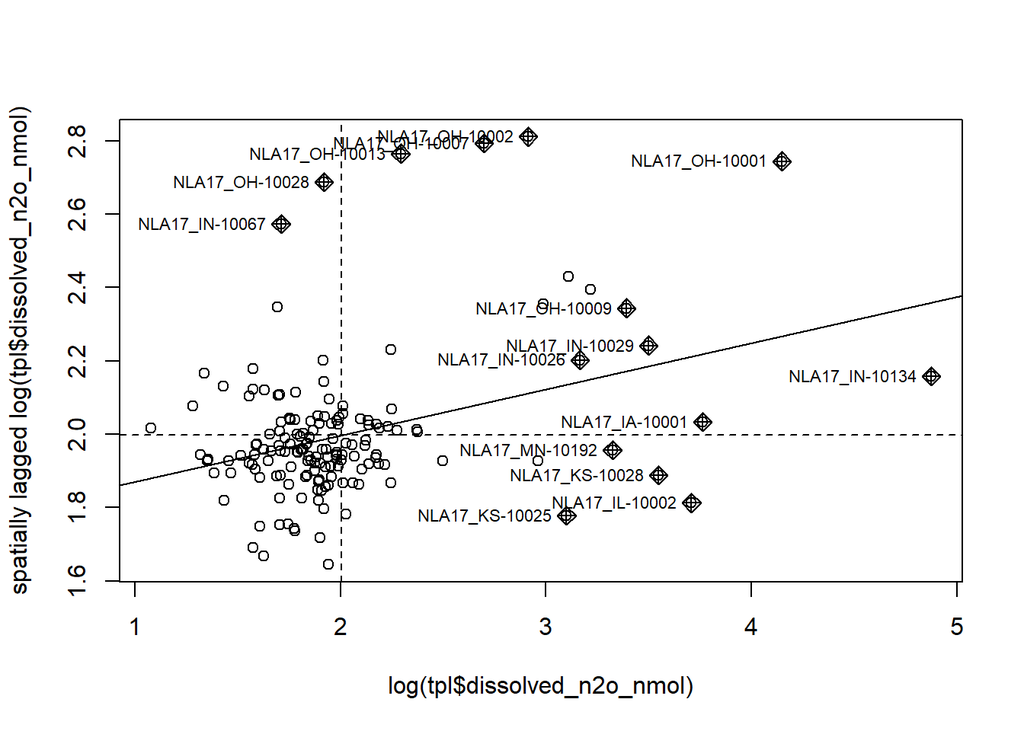

```r
moran.plot(log(tpl$dissolved_n2o_nmol), listw = dsnb1.listw, labels = tpl$site_id)
```

```r
rm(ds1coords, ds1nb1, dsnb1, dsnb1.listw, dsnb1_dist)

## UMW
umw <- dg_sf1 %>% filter(wsa9 == "UMW" & visit_no == 1 & sample_source == "DG")

umw_sp <- as(umw, "Spatial")
class(umw_sp)
```

```
## [1] "SpatialPointsDataFrame"
## attr(,"package")
## [1] "sp"
```

```r
nrow(zerodist(umw_sp)) # indicates 1 pair of identical coordinates
```

```
## [1] 0
```

```r
(zerodist(umw_sp)) # this gives the row numbers of the pair 136 & 158
```

```
##      [,1] [,2]
```

```r
View(umw) # to view rows 136, site_id NLA17_WI-10027, & 158, NLA17_WI-10127

# Warning message from code below:
# In knearneigh(ds1coords, k = 1) : knearneigh: identical points found

ds1coords <- coordinates(umw_sp)
ds1nb1 <- knn2nb(knearneigh(ds1coords, k=1), row.names = umw_sp$site_id)
# using the k=1 object to find the minimum distance at which all sites have a distance-based neighbor
dsnb1_dist <- unlist(nbdists(ds1nb1,ds1coords))
summary(dsnb1_dist)# use max distance from summary to assign distance to create neighbors
```

```
##    Min. 1st Qu.  Median    Mean 3rd Qu.    Max.
##    1216   11126   17326   21816   26455   99589
```

```r
dsnb1 <- dnearneigh(ds1coords, d1=0, d2=99590, row.names=umw_sp$site_id, longlat=FALSE)
summary(dsnb1)
```

```
## Neighbour list object:
## Number of regions: 163
## Number of nonzero links: 1970
## Percentage nonzero weights: 7.414656
## Average number of links: 12.08589
## Link number distribution:
##
##  1  2  3  4  5  6  7  8  9 10 11 12 13 14 15 16 17 18 19 20 21 22 23
##  5  3  2  7  4 10  7 12 11  7  9 12  8  8  5  2 12 13  9  8  4  3  2
## 5 least connected regions:
## NLA17_IA-10034 NLA17_MI-10035 NLA17_MI-10089 NLA17_WI-10009 NLA17_WI-10010 with 1 link
## 2 most connected regions:
## NLA17_WI-10012 NLA17_WI-10108 with 23 links
```

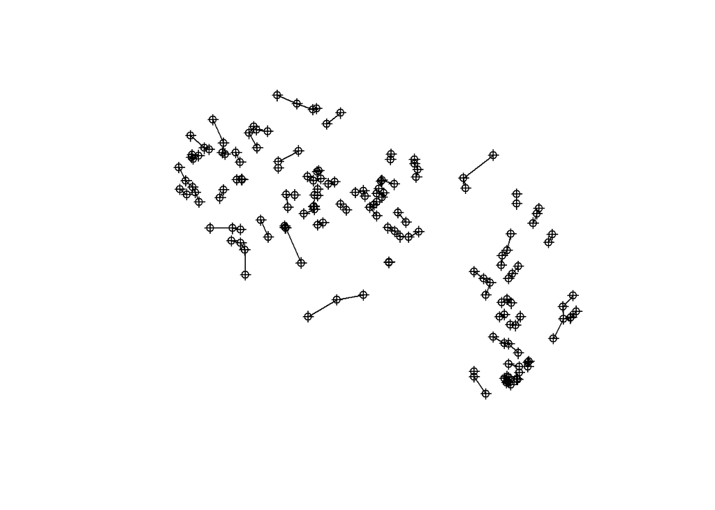

```r
plot(umw_sp)
plot(ds1nb1, ds1coords, labels = umw_sp$site_id, add = TRUE)
```

```r
dsnb1.listw <- nb2listw(dsnb1, style = "W")
summary(dsnb1.listw)
```

```
## Characteristics of weights list object:
## Neighbour list object:
## Number of regions: 163
## Number of nonzero links: 1970
## Percentage nonzero weights: 7.414656
## Average number of links: 12.08589
## Link number distribution:
##
##  1  2  3  4  5  6  7  8  9 10 11 12 13 14 15 16 17 18 19 20 21 22 23
##  5  3  2  7  4 10  7 12 11  7  9 12  8  8  5  2 12 13  9  8  4  3  2
## 5 least connected regions:
## NLA17_IA-10034 NLA17_MI-10035 NLA17_MI-10089 NLA17_WI-10009 NLA17_WI-10010 with 1 link
## 2 most connected regions:
## NLA17_WI-10012 NLA17_WI-10108 with 23 links
##
## Weights style: W
## Weights constants summary:
##     n    nn  S0       S1      S2
## W 163 26569 163 40.79153 665.959
```

```r
class(umw)
```

```
## [1] "sf"         "data.frame"
```

```r
# umw_df <- st_drop_geometry(umw)
# names(umw_df)
summary(umw$dissolved_n2o_nmol)
```

```
##    Min. 1st Qu.  Median    Mean 3rd Qu.    Max.
##   2.535   6.615   7.215  11.173   8.092 242.500
```

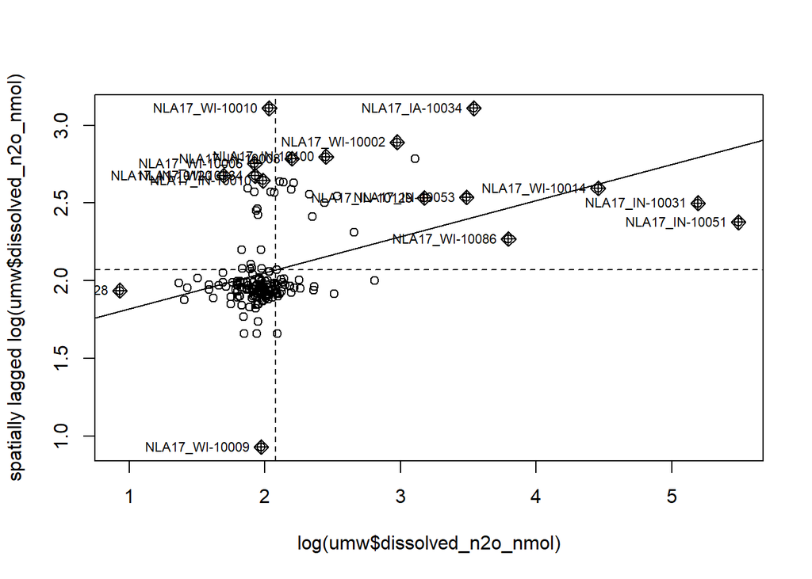

```r
moran.plot(log(umw$dissolved_n2o_nmol), listw = dsnb1.listw, labels = umw$site_id)
```

```r
rm(ds1coords, ds1nb1, dsnb1, dsnb1.listw, dsnb1_dist)

## WMT
wmt <- dg_sf1 %>% filter(wsa9 == "WMT" & visit_no == 1 & sample_source == "DG")

wmt_sp <- as(wmt, "Spatial")
class(wmt_sp)
```

```
## [1] "SpatialPointsDataFrame"
## attr(,"package")
## [1] "sp"
```

```r
# nrow(zerodist(wmt_sp)) # indicates 1 pair of identical coordinates
# (zerodist(wmt_sp)) # this gives the row numbers of the pair 136 & 158
# View(wmt) # to view rows 136, site_id NLA17_WI-10027, & 158, NLA17_WI-10127

# Warning message from code below:
# In knearneigh(ds1coords, k = 1) : knearneigh: identical points found

ds1coords <- coordinates(wmt_sp)
ds1nb1 <- knn2nb(knearneigh(ds1coords, k=1), row.names = wmt_sp$site_id)
# using the k=1 object to find the minimum distance at which all sites have a distance-based neighbor
dsnb1_dist <- unlist(nbdists(ds1nb1,ds1coords))
summary(dsnb1_dist)# use max distance from summary to assign distance to create neighbors
```

```
##    Min. 1st Qu.  Median    Mean 3rd Qu.    Max.
##    1214   11417   24930   39024   60322  295987
```

```r
dsnb1 <- dnearneigh(ds1coords, d1=0, d2=295987, row.names=wmt_sp$site_id, longlat=FALSE)
summary(dsnb1)
```

```
## Neighbour list object:
## Number of regions: 153
## Number of nonzero links: 3016
## Percentage nonzero weights: 12.88393
## Average number of links: 19.71242
## Link number distribution:
##
##  1  3  4  5  7  8  9 10 11 12 13 14 15 16 17 18 19 20 21 22 23 24 25 26 27
##  2  2  2  2  1  1  8  4  1  7  1  4  6  6  8  7  8  3  5 11 14  9 13  6  3
## 28 29 30 31 32 33 35 38
##  5  3  2  2  2  1  2  2
## 2 least connected regions:
## NLA17_NM-10044 NLA17_SD-10009 with 1 link
## 2 most connected regions:
## NLA17_OR-10013 NLA17_WA-HP001 with 38 links
```

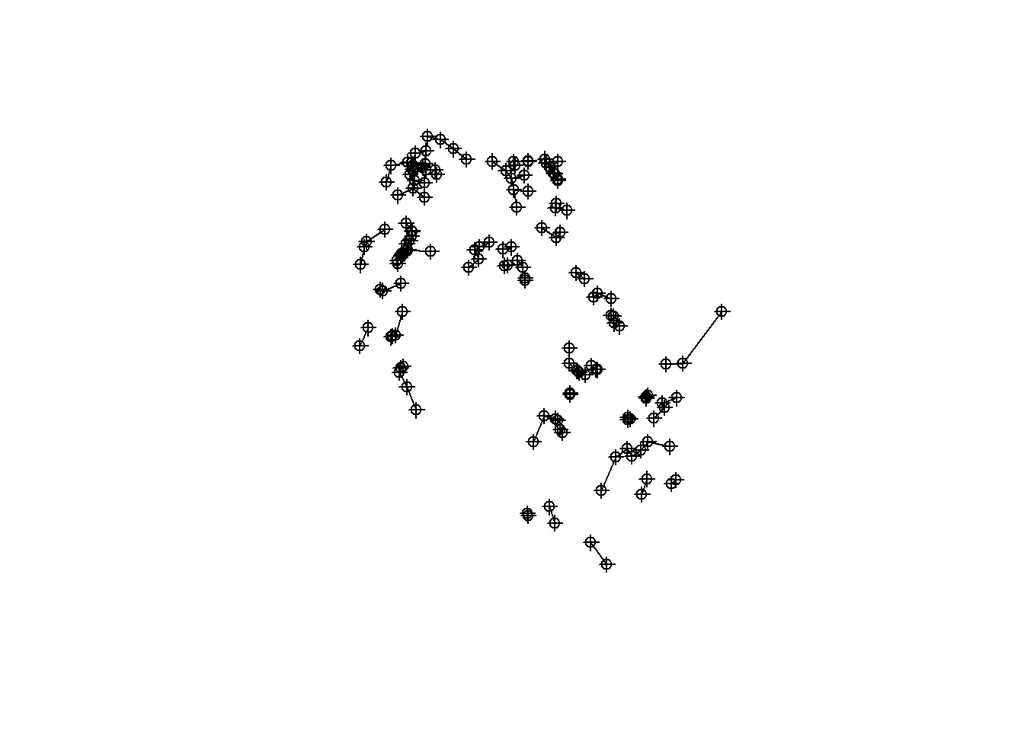

```r
plot(wmt_sp)
plot(ds1nb1, ds1coords, labels = wmt_sp$site_id, add = TRUE)
```

```r
dsnb1.listw <- nb2listw(dsnb1, style = "W")
summary(dsnb1.listw)
```

```
## Characteristics of weights list object:
## Neighbour list object:
## Number of regions: 153
## Number of nonzero links: 3016
## Percentage nonzero weights: 12.88393
## Average number of links: 19.71242
## Link number distribution:
##
##  1  3  4  5  7  8  9 10 11 12 13 14 15 16 17 18 19 20 21 22 23 24 25 26 27
##  2  2  2  2  1  1  8  4  1  7  1  4  6  6  8  7  8  3  5 11 14  9 13  6  3
## 28 29 30 31 32 33 35 38
##  5  3  2  2  2  1  2  2
## 2 least connected regions:
## NLA17_NM-10044 NLA17_SD-10009 with 1 link
## 2 most connected regions:
## NLA17_OR-10013 NLA17_WA-HP001 with 38 links
##
## Weights style: W
## Weights constants summary:
##     n    nn  S0       S1       S2
## W 153 23409 153 21.19444 618.7176
```

```r
class(wmt)
```

```
## [1] "sf"         "data.frame"
```

```r
# wmt_df <- st_drop_geometry(wmt)
# names(wmt_df)
summary(wmt$dissolved_n2o_nmol)
```

```
##    Min. 1st Qu.  Median    Mean 3rd Qu.    Max.
##   2.840   6.270   7.065   7.529   8.215  37.900
```